# INFSCI 2595 Fall 2023 Homework: 08

Assigned October 27, 2023; Due: November 3, 2023

SOLUTION GUIDE

Submission time: November 3, 2023 at 11:00PM EST

#### Collaborators

Include the names of your collaborators here.

## Overview

This homework assignment reviews important aspects of training linear models focusing on the relationship between complexity and model performance. You will fit non-Bayesian and Bayesian linear models of varying levels of complexity. You will compare their performance and examine their predictive trends. Unlike earlier assignments you will examine **both** types of uncertainty in addition to the trend. This way you gain experience with the relationship between complexity, training set performance, confidence intervals, and prediction intervals.

This assignment also requires you to fit the Bayesian models with various prior standard deviations. In this way, you learn about the prior’s role on coefficient estimates and predictive trends. These tasks introduce to the concept that the prior **regularizes** coefficients.

Lastly, you are introduced to non-Bayesian regularization with Lasso regression via the `glmnet` package. If you do not have `glmnet` installed **PLEASE** download it before starting the assignment.

**IMPORTANT**: The RMarkdown assumes you have downloaded the data set (CSV file) to the same directory you saved the template Rmarkdown file. If you do not have the CSV files in the correct location, the data will not be loaded correctly.

### IMPORTANT!!!

Certain code chunks are created for you. Each code chunk has `eval=FALSE` set in the chunk options. You **MUST** change it to be `eval=TRUE` in order for the code chunks to be evaluated when rendering the document.

You are free to add more code chunks if you would like.

## Load packages

This assignment will use packages from the `tidyverse` suite as well as the `coefplot` package. Those packages are imported for you below.

```r
library(tidyverse)
```

```r
library(coefplot)
```

This assignment also uses the `splines` and `MASS` packages. Both are installed with base `R` and so you do not need to download any additional packages to complete the assignment.

The last question in the assignment uses the `glmnet` package. As stated previously, please download and install `glmnet` if you do not currently have it.

## Problem 01

You will fit and compare **6 models** of varying complexity using **non-Bayesian methods**. The unknown parameters will be be estimated by finding their Maximum Likelihood Estimates (MLE). You are allowed to use the `lm()` function for this problem.

The data are loaded in the code chunk and a glimpse is shown for you below. There are 2 continuous inputs, `x1` and `x2`, and a continuous response `y`.

```r
hw_file_path <- 'hw08_data.csv'

df <- readr::read_csv(hw_file_path, col_names = TRUE)
df %>% glimpse()
```

```
## Rows: 100
## Columns: 3
## $ x1 <dbl> -0.30923281, 0.63127211, -0.68276690, 0.26930562, 0.37252021, 1.296…
## $ x2 <dbl> 0.308779853, -0.547919793, 2.166449412, 1.209703658, 0.785485991, -…
## $ y  <dbl> 0.43636596, 1.37562976, -0.84366730, -0.43080811, 0.77456951, 1.361…
```

### 1a)

**Create a scatter plot between the response, `y`, and each input using `ggplot()`.**

**Based on the visualizations, do you think there are trends between either input and the response?**

#### SOLUTION

There are several ways you can answer this question. You can create separate scatter plots between the response and the inputs. The code chunk below shows the scatter plot between `y` and `x1`.

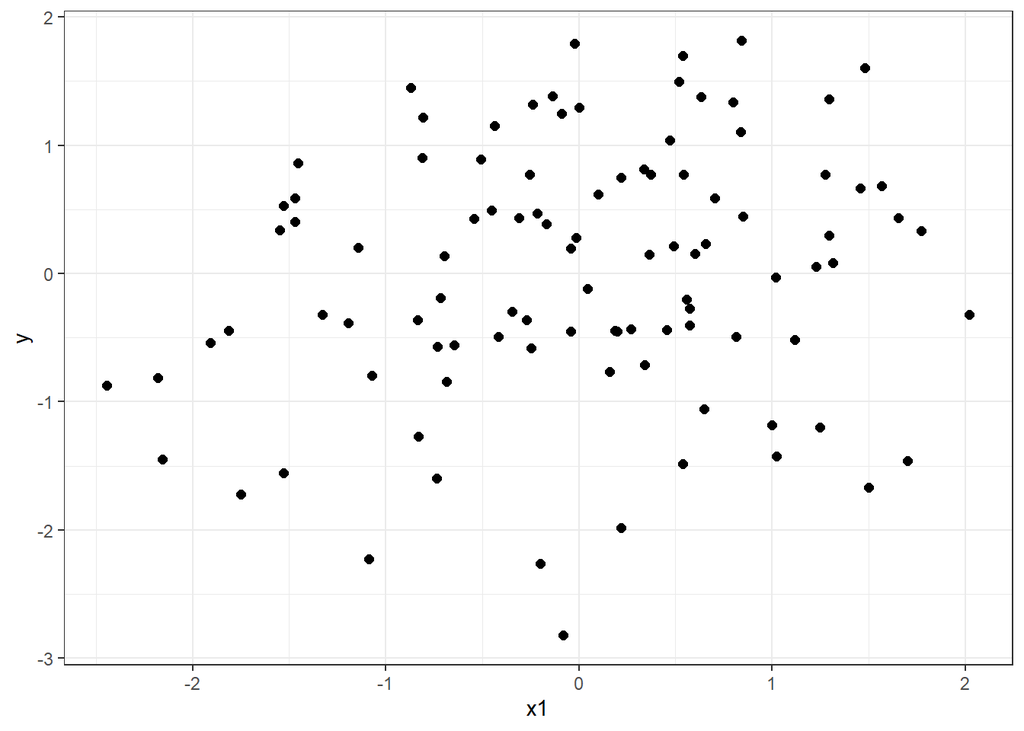

```r
df %>%
  ggplot(mapping = aes(x = x1, y = y)) +
  geom_point(size = 2) +
  theme_bw()
```

The code chunk below shows the scatter plot between `y` and `x2`.

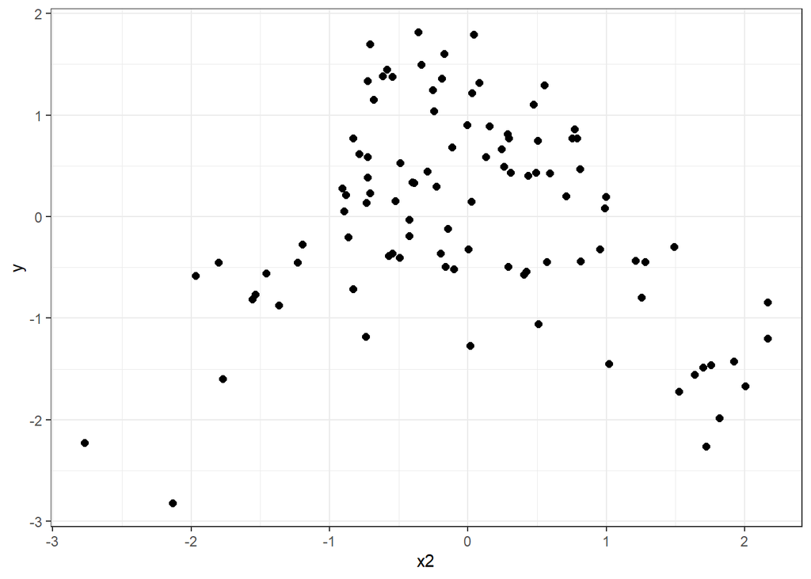

```r
df %>%
  ggplot(mapping = aes(x = x2, y = y)) +
  geom_point(size = 2) +
  theme_bw()
```

Alternatively, we can create one graphic that shows the relationships between the response and the inputs. The different inputs will be associated with separate *facets* or subplots in the graphic. To do so, we need to reshape the `df` dataframe from its current wide-format to a long-format. We need to “gather” the input variables into two new columns. One column stores the name of the input and another column stores the value of the input. The reshaped long-format data is created in the code chunk below. The `glimpse()` function is used to show the structure. The long-format essentially “stacks” the input columns on top of each other, but because we did not “gather” the response, we have maintained the output-to-input relationship in the original data set.

```r
df %>%
  tibble::rowid_to_column() %>%
  pivot_longer(!c("rowid", "y")) %>%
  glimpse()
```

```
## Rows: 200
## Columns: 4
## $ rowid <int> 1, 1, 2, 2, 3, 3, 4, 4, 5, 5, 6, 6, 7, 7, 8, 8, 9, 9, 10, 10, 11…
## $ y     <dbl> 0.43636596, 0.43636596, 1.37562976, 1.37562976, -0.84366730, -0.…
## $ name  <chr> "x1", "x2", "x1", "x2", "x1", "x2", "x1", "x2", "x1", "x2", "x1"…
## $ value <dbl> -0.309232810, 0.308779853, 0.631272114, -0.547919793, -0.6827669…
```

The long-format data is pipped to `ggplot()` in the code chunk below and the `facet_wrap()` function is used to create the facets per input. The `scales` argument in `facet_wrap()` is set to `'free_x'` so that the x-axis scale is different in each facet.

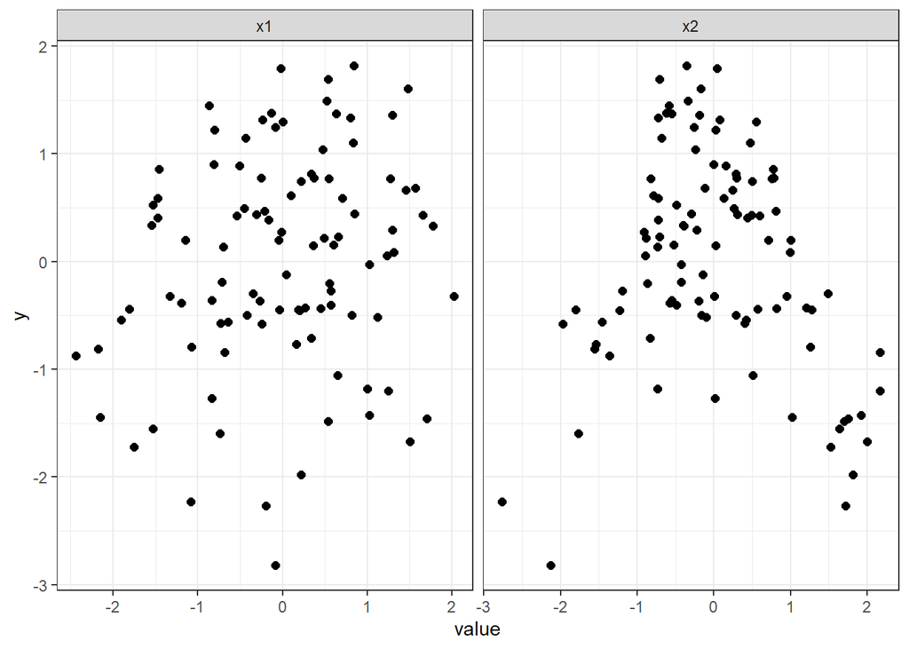

```r
df %>%
  tibble::rowid_to_column() %>%
  pivot_longer(!c("rowid", "y")) %>%
  ggplot(mapping = aes(x = value, y = y)) +
  geom_point(size = 2) +
  facet_wrap(~name, scales = "free_x") +
  theme_bw()
```

Lastly, we can make use of the tidy select helper function `starts_with()` to easily select the inputs for reshaping. We can do this because all inputs have variable names that start with `x`. The tidy select helper functions, `starts_with()`, `ends_with()`, and `contains()` can be quite helpful when the variables have common patterns and naming conventions.

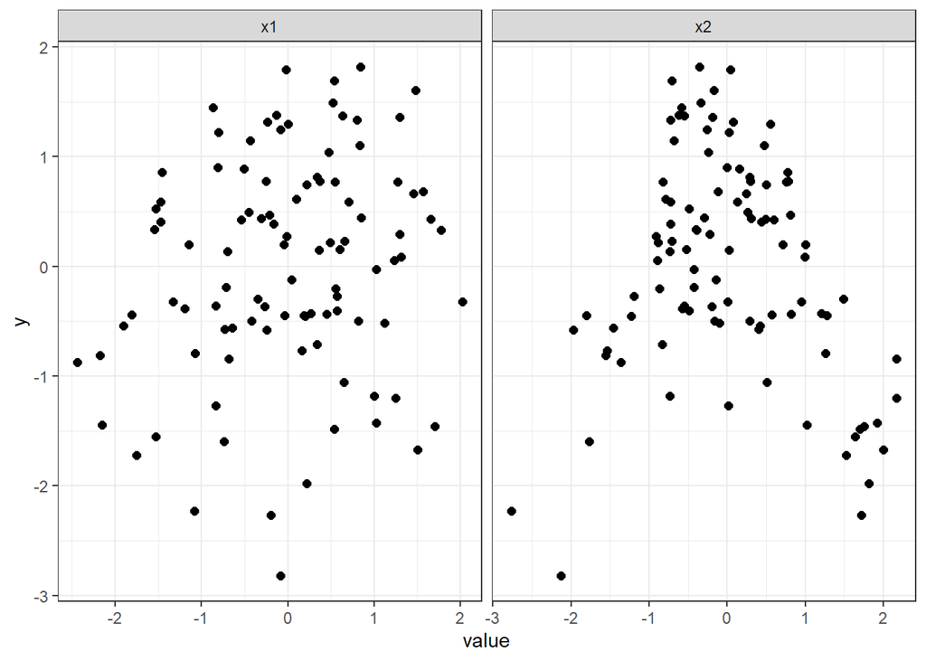

```r
df %>%
  tibble::rowid_to_column() %>%
  pivot_longer(starts_with('x')) %>%
  ggplot(mapping = aes(x = value, y = y)) +
  geom_point(size = 2) +
  facet_wrap(~name, scales = "free_x") +
  theme_bw()
```

Regardless of how the scatter plots were created, you should see that it is difficult to identify a clear trend between `y` and the `x1` input. The response has lower values when `x2` is negative and when `x2` is positive. The response has higher values when `x2` is near its center. Thus, the response might have a parabolic-like relationship with respect to `x2`.

### 1b)

You will fit multiple models of varying complexity in this problem. You will start with *linear additive features* which *add* the effect of one input with the other. Your model therefore *controls* for both inputs.

**Fit a model with linear additive features to predict the response, `y`. Use the formula interface and the `lm()` function to fit the model. Assign the result to the `mod01` object.**

**Visualize the coefficient summaries with the `coefplot()` function. Are any of the features statistically significant?**

#### SOLUTION

The linear additive model is fit in the code chunk below.

```r
mod01 <- lm( y ~ x1 + x2, data = df )
```

The coefficient summaries are visualized in the figure below. It looks like `x1` has a statistically significant linear relationship with the response. The `x2` input however, does not have a statistically significant linear relationship with the response since the 95% confidence interval on its slope contains 0.

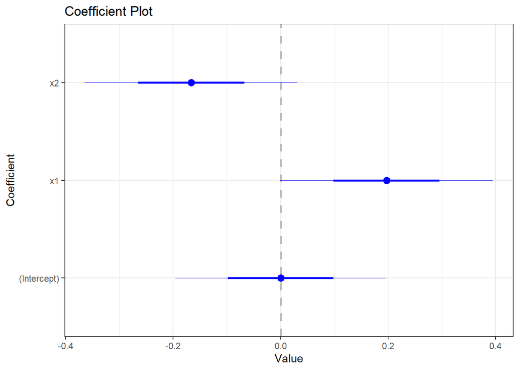

```r
mod01 %>% coefplot::coefplot() +
  theme_bw() +
  theme(legend.position = 'none')
```

Although not required, we can check our visual analysis by printing the linear model summary. The p-value for `x1` is just less than 0.05, representing that the `x1` predictor is considered to be statistically significant, at the 5% significance level. The `*` displayed to the right of the p-value is used to denote that the predictor meets that significance level.

```r
mod01 %>% summary()
```

```
##
## Call:
## lm(formula = y ~ x1 + x2, data = df)
##
## Residuals:
##      Min       1Q   Median       3Q      Max
## -3.16127 -0.62627 -0.01296  0.75883  1.80516
##
## Coefficients:
##               Estimate Std. Error t value Pr(>|t|)
## (Intercept)  2.632e-17  9.798e-02   0.000   1.0000
## x1           1.970e-01  9.905e-02   1.989   0.0495 *
## x2          -1.665e-01  9.905e-02  -1.681   0.0960 .
## ---
## Signif. codes:  0 '***' 0.001 '**' 0.01 '*' 0.05 '.' 0.1 ' ' 1
##
## Residual standard error: 0.9798 on 97 degrees of freedom
## Multiple R-squared:  0.05945,    Adjusted R-squared:  0.04005
## F-statistic: 3.065 on 2 and 97 DF,  p-value: 0.05118
```

### 1c)

As discussed in lecture, we can derive features from inputs. We have worked with polynomial features and spline-based features in previous assignments. Features can also be derived as the products between different inputs. A feature calculated as the **product** of multiple inputs is usually referred to as the **interaction** between those inputs.

In the formula interface, a product of two inputs is denoted by the `:`. And so if we want to include just the multiplication of `x1` and `x2` in a model we would type, `x1:x2`. We can then include **main-effect** terms by including the additive features within the formula. Thus, the formula for a model with additive features and the interaction between `x1` and `x2` is:

`y ~ x1 + x2 + x1:x2`

However, the formula interface provides a short-cut to create main effects and interaction features. In the formula interface, the `*` operator will generate all main-effects and all interactions for us.

**Fit a model with all main-effect and all-interaction features between `x1` and `x2` using the short-cut `*` operator within the formula interface. Assign the result to the `mod02` object.**

**Visualize the coefficient summaries with the `coefplot()` function. How many features are present in the model? Are any of the features statistically significant?**

#### SOLUTION

The linear model with linear main-effects and the interaction (product) between `x1` and `x2` is fit in the code chunk below. The predictors (features) are created using the `*` “short cut” operator.

```r
mod02 <- lm( y ~ x1*x2, data = df )
```

The coefficient summaries reveal that we have 3 coefficients in addition to the intercept. Our model includes the coefficient acting on the `x1` main-effect, the coefficient acting on the `x2` main-effect, and the interaction coefficient, `x1:x2`. As we see below all three features are statistically significant! None of the 95% confidence intervals contain zero! Accounting for the interaction between `x1` and `x2` has therefore not only identified the interaction is significant, but the linear relationship between the response and `x2` is now also significant!

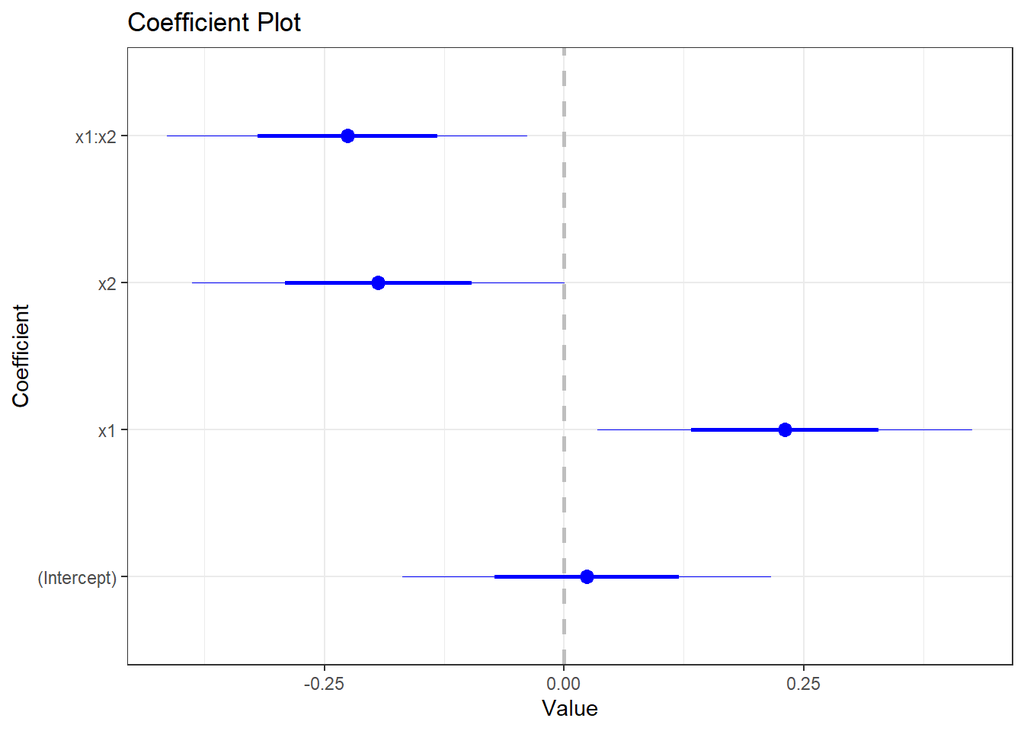

```r
mod02 %>% coefplot::coefplot() +
  theme_bw() +
  theme(legend.position = 'none')
```

Again, we can check the linear model summary to confirm our visual analysis. You did not have to do this, but as we see below all 3 features are considered to be significant at the 5% significance level.

```r
mod02 %>% summary()
```

```
##
## Call:
## lm(formula = y ~ x1 * x2, data = df)
##
## Residuals:
##     Min      1Q  Median      3Q     Max
## -3.2016 -0.6424 -0.0518  0.8017  1.7827
##
## Coefficients:
##             Estimate Std. Error t value Pr(>|t|)
## (Intercept)  0.02413    0.09616   0.251   0.8024
## x1           0.23061    0.09769   2.361   0.0203 *
## x2          -0.19364    0.09734  -1.989   0.0495 *
## x1:x2       -0.22607    0.09389  -2.408   0.0180 *
## ---
## Signif. codes:  0 '***' 0.001 '**' 0.01 '*' 0.05 '.' 0.1 ' ' 1
##
## Residual standard error: 0.9564 on 96 degrees of freedom
## Multiple R-squared:  0.113,  Adjusted R-squared:  0.08529
## F-statistic: 4.077 on 3 and 96 DF,  p-value: 0.009004
```

### 1d)

The `*` operator will interact more than just inputs. We can interact expressions or groups of features together. To interact one group of features by another group of features, we just need to enclose each group within parenthesis, `()`, and separate them by the `*` operator. The line of code below shows how this works with the `<expression 1>` and `<expression 2>` as place holders for any expression we want to use.

`(<expression 1>) * (<expression 2>)`

**Fit a model which interacts linear and quadratic features from `x1` with linear and quadratic features from `x2`. Assign the result to the `mod03` object.**

**Visualize the coefficient summaries with the `coefplot()` function. How many features are present in the model? Are any of the features statistically significant?**

*HINT*: Remember to use the `I()` function when typing polynomials in the formula interface.

#### SOLUTION

The linear and quadratic features associated with `x1` are interacted with the `x2` linear and quadratic features in the model below.

```r
mod03 <- lm( y ~ (x1 + I(x1^2)) * (x2 + I(x2^2)), data = df )
```

The `mod03` model has many more features than just the two inputs in our data set. This a reminder that we can derive (calculate) as many features as we want from the inputs. The number of features of a linear model does not have to equal the number of inputs!

As shown by the figure below, the `mod03` model has 8 features plus the intercept. Thus, there are total of 9 coefficients that needed to be estimated. Including the quadratic polynomials and their interactions have completely changed the interpretation of significant features! The linear `x1` and `x2` main-effect features are no longer statistically significant. The interaction between the two inputs, `x1:x2`, is also not statistically significant! The only statistically significant feature in `mod03` is the quadratic feature associated with `x2`.

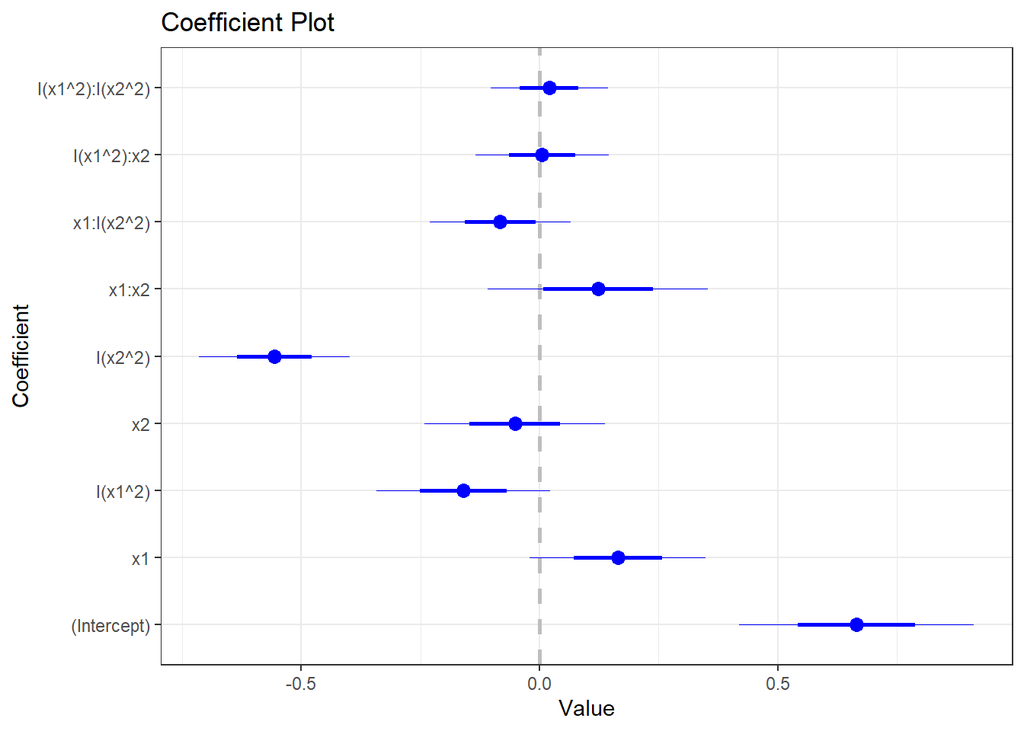

```r
mod03 %>% coefplot::coefplot() +
  theme_bw() +
  theme(legend.position = 'none')
```

Again, we can check with `summary()` but you were not required to do so. The print display from the code chunk below shows only `I(x2^2)` is statistically significant.

```r
mod03 %>% summary()
```

```
##
## Call:
## lm(formula = y ~ (x1 + I(x1^2)) * (x2 + I(x2^2)), data = df)
##
## Residuals:
##      Min       1Q   Median       3Q      Max
## -1.68423 -0.41328 -0.00785  0.46938  1.29854
##
## Coefficients:
##                  Estimate Std. Error t value Pr(>|t|)
## (Intercept)      0.665298   0.123052   5.407 5.13e-07 ***
## x1               0.164473   0.092344   1.781   0.0782 .
## I(x1^2)         -0.160376   0.091124  -1.760   0.0818 .
## x2              -0.051980   0.094540  -0.550   0.5838
## I(x2^2)         -0.556463   0.078811  -7.061 3.21e-10 ***
## x1:x2            0.122791   0.115453   1.064   0.2903
## x1:I(x2^2)      -0.082521   0.073847  -1.117   0.2667
## I(x1^2):x2       0.005341   0.069932   0.076   0.9393
## I(x1^2):I(x2^2)  0.020387   0.061572   0.331   0.7413
## ---
## Signif. codes:  0 '***' 0.001 '**' 0.01 '*' 0.05 '.' 0.1 ' ' 1
##
## Residual standard error: 0.7024 on 91 degrees of freedom
## Multiple R-squared:  0.5465, Adjusted R-squared:  0.5067
## F-statistic: 13.71 on 8 and 91 DF,  p-value: 7.252e-13
```

### 1e)

Let’s now try a more complicated model.

**Fit a model which interacts linear, quadratic, cubic, and quartic (4th degree) polynomial features from `x1` with linear, quadratic, cubic, and quartic (4th degree) polynomial features from `x2`. Assign the result to the `mod04` object.**

**Visualize the coefficient summaries with the `coefplot()` function. Are any of the features statistically significant?**

#### SOLUTION

The `mod04` model is fit in the code chunk below. Typing the formula might be tedious, but it demonstrates we are adding more complexity to our model by including more features.

```r
mod04 <- lm( y ~ (x1 + I(x1^2) + I(x1^3) + I(x1^4)) * (x2 + I(x2^2) + I(x2^3) + I(x2^4)),
             data = df )
```

The coefficient summaries are displayed below. We can see that there are many features in this model! It appears that none of the features are statistically significant. The intercept is statistically significant, but usually we are focused on interpreting the behavior of the predictors or features in our models. The intercept is the average response when the features equal 0.

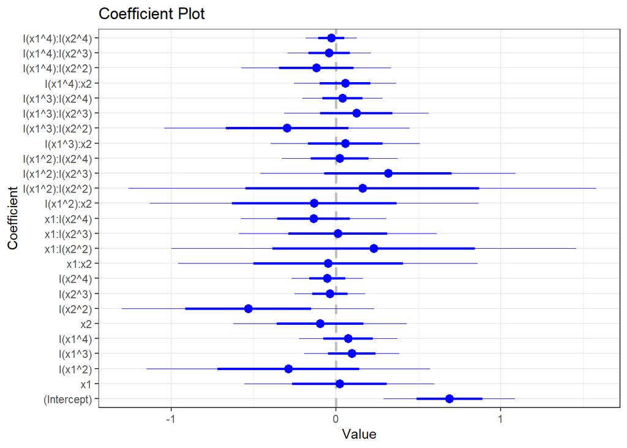

```r
mod04 %>% coefplot::coefplot() +
  theme_bw() +
  theme(legend.position = 'none')
```

### 1f)

Let’s try using spline based features. We will use a high degree-of-freedom natural spline applied to `x1` and interact those features with polynomial features derived from `x2`.

**Fit a model which interacts a 12 degree-of-freedom natural (DOF) spline from `x1` with linear and quadrtic polyonomial features from `x2`. Assign the result to `mod05`.**

**Visualize the coefficient summaries with the `coefplot()` function. Are any of the features statistically significant?**

#### SOLUTION

This model sounds like it should be rather complicated since we are creating 12 features associated with `x1` via natural splines. These features are interacting with `x2` features and thus the slope applied to the spline-derived features depend on `x2`!

```r
mod05 <- lm(y ~ splines::ns(x1, 12) * (x2 + I(x2^2)), data = df)
```

The coefficient summaries are visualized in the figure below. Again, we see a large number of features present in the model. It looks like none of the features are statistically significant.

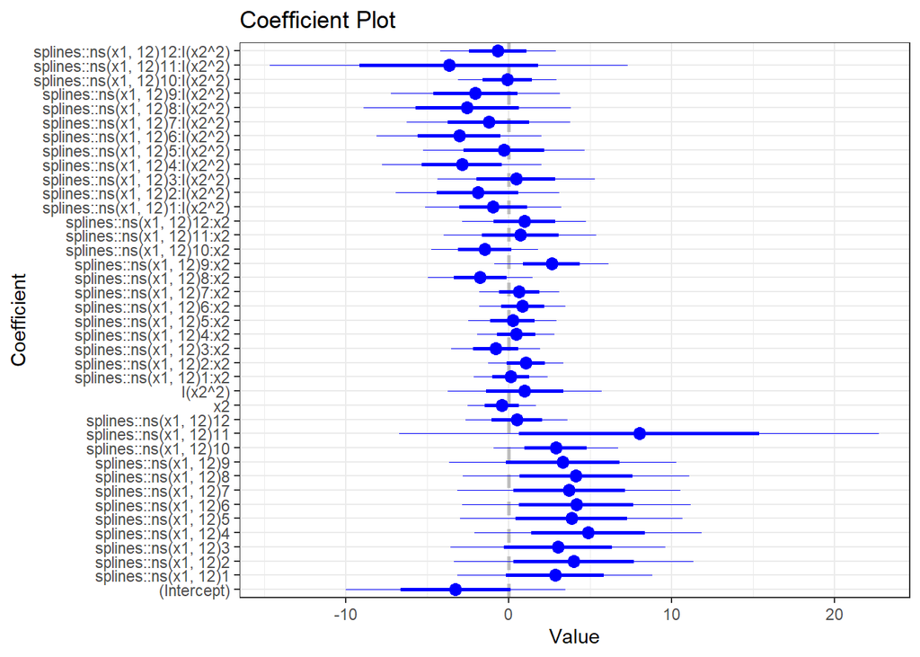

```r
mod05 %>% coefplot::coefplot() +
  theme_bw() +
  theme(legend.position = 'none')
```

### 1g)

Let’s fit one final model.

**Fit a model which interacts a 12 degree-of-freedom natural spline from `x1` with linear, quadrtic, cubic, and quartic (4th degree) polyonomial features from `x2`. Assign the result to `mod05`.**

**Visualize the coefficient summaries with the `coefplot()` function. Are any of the features statistically significant?**

#### SOLUTION

This is the most complex model we are fitting in this assignment.

```r
mod06 <- lm(y ~ splines::ns(x1, 12) * (x2 + I(x2^2) + I(x2^3) + I(x2^4)), data = df)
```

The coefficient summary plot below reveals a large number of features in the model. It does not appear that any of the features are statistically significant.

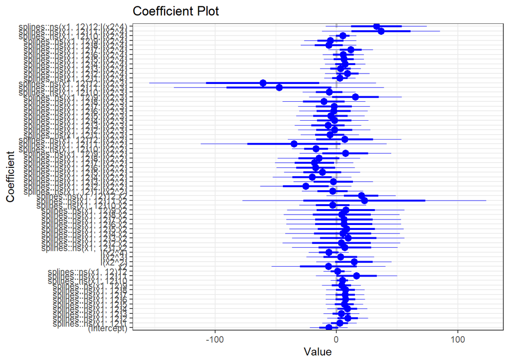

```r
mod06 %>% coefplot::coefplot() +
  theme_bw() +
  theme(legend.position = 'none')
```

We do not have to count the number of features from the plot if we want to know the number of features present in the model. We can use the `coef()` function to extract the coefficient estimates and then check the length of that vector. Since the intercept is a coefficient, the intercept is included below and so we created 64 features for the `mod06` model even though we have just 2 inputs!

```r
mod06 %>% coef() %>% length()
```

```
## [1] 65
```

### 1h)

Now that you have fit multiple models of varying complexity, it is time to identify the best performing model.

**Identify the best model considering training set only performance metrics. Which model is best according to R-squared? Which model is best according to AIC? Which model is best according to BIC?**

*HINT*: The `brooom::glance()` function can be helpful here. The `broom` package is installed with `tidyverse` and so you should have it already.

#### SOLUTION

There are multiple ways to compile the training set performance metrics. Your approach does not have to be the same as mine, but your the displayed results should be consistent with mine. Below, I define a function `extract_metrics()` which is a wrapper around `broom::glance()` so I can include the name of the model with the performance metrics.

```r
extract_metrics <- function(mod, mod_name)
{
  broom::glance(mod) %>% mutate(mod_name = mod_name)
}
```

The `extract_metrics()` function is applied functionally to each `lm()` model object and the results are compiled into a dataframe with `purrr::map_dfr()`.

```r
all_metrics <- purrr::map2_dfr(list(mod01, mod02, mod03, mod04, mod05, mod06),
                               as.character(1:6),
                               extract_metrics)
```

A glimpse of the `all_metrics` object is shown below. Each row is a model and the columns correspond to various performance metrics associated with the training set performance.

```r
all_metrics %>% glimpse()
```

```
## Rows: 6
## Columns: 13
## $ r.squared     <dbl> 0.05944659, 0.11301022, 0.54654230, 0.59872846, 0.699279…
## $ adj.r.squared <dbl> 0.04005374, 0.08529179, 0.50667789, 0.47032157, 0.511945…
## $ sigma         <dbl> 0.9797685, 0.9564038, 0.7023689, 0.7277901, 0.6986092, 0…
## $ statistic     <dbl> 3.065387, 4.077078, 13.710030, 4.662744, 3.732791, 1.960…
## $ p.value       <dbl> 5.117971e-02, 9.004490e-03, 7.252057e-13, 1.505723e-07, …
## $ df            <dbl> 2, 3, 8, 24, 38, 64
## $ logLik        <dbl> -138.32699, -135.39525, -101.84867, -95.73549, -81.31266…
## $ AIC           <dbl> 284.6540, 280.7905, 223.6973, 243.4710, 242.6253, 262.50…
## $ BIC           <dbl> 295.0747, 293.8163, 249.7490, 311.2054, 346.8321, 434.44…
## $ deviance      <dbl> 93.11479, 87.81199, 44.89231, 39.72588, 29.77135, 21.592…
## $ df.residual   <int> 97, 96, 91, 75, 61, 35
## $ nobs          <int> 100, 100, 100, 100, 100, 100
## $ mod_name      <chr> "1", "2", "3", "4", "5", "6"
```

Although `broom::glance()` gives us a lot of different quantities, we are focusing on R-squared, AIC, and BIC. Those three metrics are visualized in a single graphic in the figure below. The x-axis is the model name displayed as an integer. The facet corresponds to the metric with AIC on the left, BIC in the middle, and R-squared displayed in the right facet. We are assessing performance on the training set at the moment, and thus the R-squared metric is representing which model is most correlated to the **training** data. As we see below, the model with the most features, `mod06`, has the highest training set R-squared. Thus, if we only considered the performance on the training set we would choose whichever model has the most **degrees-of-freedom**. However, the AIC and BIC metrics **penalize** the performance (the “goodness of fit”) based on the number of unknown parameters that must be estimated. The AIC and BIC metrics extracted by `broom::glance()` are the conventional formulation and thus the lower the value the better. As we see below, both AIC and BIC agree that `mod03` is the best. Thus even though `mod03` does not perform as well as `mod06` on the training set (as shown by R-squared), the penalty term within AIC and BIC is stating the added flexibility in `mod06` is **“not worth it”**. The added flexibility due to the larger number of features in `mod06` leads to **overfitting** and thus we expect `mod03` will do better on **new data** than `mod06`.

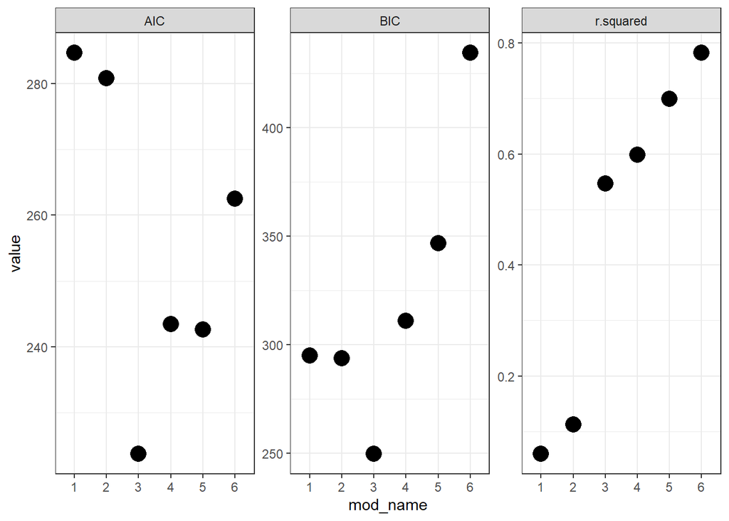

```r
all_metrics %>%
  select(mod_name, df, r.squared, AIC, BIC) %>%
  pivot_longer(!c("mod_name", "df")) %>%
  ggplot(mapping = aes(x = mod_name, y = value)) +
  geom_point(size = 5) +
  facet_wrap(~name, scales = "free_y") +
  theme_bw()
```

## Problem 02

Now that you know which model is best, let’s visualize the predictive trends from the six models. This will help us better understand their performance and behavior.

### 2a)

You will define a prediction or visualization test grid. This grid will allow you to visualize behavior with respect to `x1` for multiple values of `x2`.

**Create a grid of input values where `x1` consists of 101 evenly spaced points between -3.2 and 3.2 and `x2` is 9 evenly spaced points between -3 and 3. The `expand.grid()` function is started for you and the data type conversion is provided to force the result to be a `tibble`.**

#### SOLUTION

The `x1` and `x2` columns of the `viz_grid` tibble are created viz the `expand.grid()` function. The `seq()` function is used with the `length.out` argument is used to specify the length of the vector of evenly spaced values *from* a lower bound *to* an upper bound.

```r
viz_grid <- expand.grid(x1 = seq(-3.2, 3.2, length.out = 101),
                        x2 = seq(-3, 3, length.out = 9),
                        KEEP.OUT.ATTRS = FALSE,
                        stringsAsFactors = FALSE) %>%
  as.data.frame() %>% tibble::as_tibble()
```

You were not required to do this, but a glimpse of the `viz_grid` tibble is shown below. We are making predictions at 909 combinations of the two inputs. The `expand.grid()` function creates the full-factorial grid of combinations of the 101 values of `x1` and 9 values of `x2`.

```r
viz_grid %>% glimpse()
```

```
## Rows: 909
## Columns: 2
## $ x1 <dbl> -3.200, -3.136, -3.072, -3.008, -2.944, -2.880, -2.816, -2.752, -2.…
## $ x2 <dbl> -3, -3, -3, -3, -3, -3, -3, -3, -3, -3, -3, -3, -3, -3, -3, -3, -3,…
```

### 2b)

You will make predictions for each of the models and visualize their trends. A function, `tidy_predict()`, is created for you which assembles the predicted mean trend, the confidence interval, and the prediction interval into a `tibble` for you. The result include the input values to streamline making the visualizations.

```r
tidy_predict <- function(mod, xnew)
{
  pred_df <- predict(mod, xnew, interval = "confidence") %>%
    as.data.frame() %>% tibble::as_tibble() %>%
    dplyr::select(pred = fit, ci_lwr = lwr, ci_upr = upr) %>%
    bind_cols(predict(mod, xnew, interval = 'prediction') %>%
                as.data.frame() %>% tibble::as_tibble() %>%
                dplyr::select(pred_lwr = lwr, pred_upr = upr))

  xnew %>% bind_cols(pred_df)
}
```

The first argument to the `tidy_predict()` function is a `lm()` model object and the second argument is new or test dataframe of inputs. When working with `lm()` and its `predict()` method, the functions will create the test design matrix consistent with the training design basis. It does so via the model object’s formula which is contained within the `lm()` model object. The `lm()` object therefore takes care of the heavy lifting for us!

**Make predictions with each of the six models you fit in Problem 01 using the visualization grid, `viz_grid`. The predictions should be assigned to the variables `pred_lm_01` through `pred_lm_06` where the number is consistent with the model number fit previously.**

#### SOLUTION

Predictions are made by the 6 models in the code chunk below.

```r
pred_lm_01 <- tidy_predict(mod01, viz_grid)

pred_lm_02 <- tidy_predict(mod02, viz_grid)

pred_lm_03 <- tidy_predict(mod03, viz_grid)

pred_lm_04 <- tidy_predict(mod04, viz_grid)

pred_lm_05 <- tidy_predict(mod05, viz_grid)

pred_lm_06 <- tidy_predict(mod06, viz_grid)
```

A glimpse of the `pred_lm_01` tibble is shown below.

```r
pred_lm_01 %>% glimpse()
```

```
## Rows: 909
## Columns: 7
## $ x1       <dbl> -3.200, -3.136, -3.072, -3.008, -2.944, -2.880, -2.816, -2.75…
## $ x2       <dbl> -3, -3, -3, -3, -3, -3, -3, -3, -3, -3, -3, -3, -3, -3, -3, -…
## $ pred     <dbl> -0.130874441, -0.118267841, -0.105661241, -0.093054640, -0.08…
## $ ci_lwr   <dbl> -0.9683365, -0.9472865, -0.9263426, -0.9055079, -0.8847859, -…
## $ ci_upr   <dbl> 0.7065876, 0.7107508, 0.7150201, 0.7193986, 0.7238898, 0.7284…
## $ pred_lwr <dbl> -2.248111, -2.232179, -2.216317, -2.200525, -2.184803, -2.169…
## $ pred_upr <dbl> 1.986362, 1.995644, 2.004994, 2.014415, 2.023907, 2.033469, 2…
```

The columns are the same for the predictions associated with all of the models. As a confirmation, the glimpse for the predictions associated is shown below. We see that the columns in `pred_lm_06` are the same as the columns in `pred_lm_01`.

```r
pred_lm_06 %>% glimpse()
```

```
## Rows: 909
## Columns: 7
## $ x1       <dbl> -3.200, -3.136, -3.072, -3.008, -2.944, -2.880, -2.816, -2.75…
## $ x2       <dbl> -3, -3, -3, -3, -3, -3, -3, -3, -3, -3, -3, -3, -3, -3, -3, -…
## $ pred     <dbl> -1296.670050, -1225.806915, -1154.943780, -1084.080645, -1013…
## $ ci_lwr   <dbl> -5886.1282, -5565.1235, -5244.1380, -4923.1754, -4602.2404, -…
## $ ci_upr   <dbl> 3292.7881, 3113.5097, 2934.2505, 2755.0141, 2575.8054, 2396.6…
## $ pred_lwr <dbl> -5886.1285, -5565.1238, -5244.1383, -4923.1757, -4602.2408, -…
## $ pred_upr <dbl> 3292.7884, 3113.5100, 2934.2508, 2755.0144, 2575.8057, 2396.6…
```

### 2c)

You will now visualize the predictive trends and the confidence and prediction intervals for each model. The `pred` column in of each `pred_lm_` objects is the predictive mean trend. The `ci_lwr` and `ci_upr` columns are the lower and upper bounds of the confidence interval, respectively. The `pred_lwr` and `pred_upr` columns are the lower and upper bounds of the prediction interval, respectively.

You will use `ggplot()` to visualize the predictions. You will use `geom_line()` to visualize the mean trend and `geom_ribbon()` to visualize the uncertainty intervals.

**Visualize the predictions of each model on the visualization grid. Pipe the `pred_lm_` object to `ggplot()` and map the `x1` variable to the x-aesthetic. Add three geometric object layers. The first and second layers are each `geom_ribbon()` and the third layer is `geom_line()`. In the `geom_line()` layer map the `pred` variable to the `y` aesthetic. In the first `geom_ribbon()` layer, map `pred_lwr` and `pred_upr` to the `ymin` and `ymax` aesthetics, respectively. Hard code the `fill` to be orange in the first `geom_ribbon()` layer (outside the `aes()` call). In the second `geom_ribbon()` layer, map `ci_lwr` and `ci_upr` to the `ymin` and `ymax` aesthetics, respectively. Hard code the `fill` to be `grey` in the second `geom_ribbon()` layer (outside the `aes()` call). Include `facet_wrap()` with the facets with controlled by the `x2` variable.**

**To help compare the visualizations across models include a `coord_cartesian()` layer with the `ylim` argument set to `c(-7,7)`.**

**Each model’s prediction visualization should be created in a separate code chunk.**

#### SOLUTION

The predictions from `mod01` are shown below. We see a slightly linear relationship between the trend as `x1` increases. The predictions are consistent with the coefficient summaries we looked at previously.

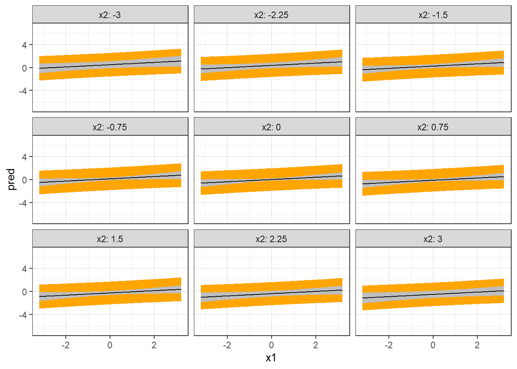

```r
pred_lm_01 %>%
  ggplot(mapping = aes(x = x1)) +
  geom_ribbon(mapping = aes(ymin = pred_lwr, ymax = pred_upr),
              fill = 'orange') +
  geom_ribbon(mapping = aes(ymin = ci_lwr, ymax = ci_upr),
              fill = 'grey') +
  geom_line(mapping = aes(y = pred),
            color = 'black') +
  coord_cartesian(ylim = c(-7, 7)) +
  facet_wrap(~x2, labeller = "label_both") +
  theme_bw()
```

The predictions associated with `mod02` are shown below. `mod02` includes the interaction between `x1` and `x2`. Thus, we see the trend with respect to `x1` changing as `x2` changes across the facets.

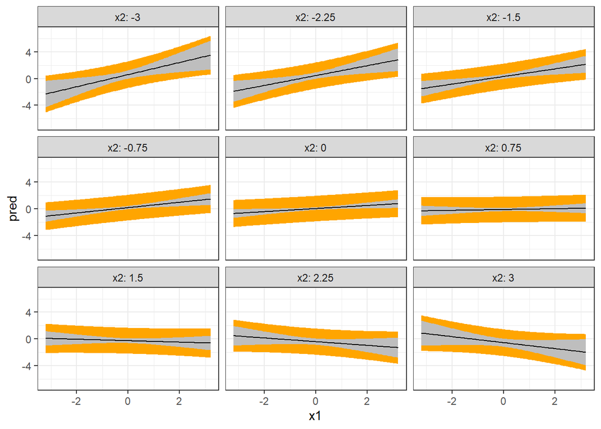

```r
pred_lm_02 %>%
  ggplot(mapping = aes(x = x1)) +
  geom_ribbon(mapping = aes(ymin = pred_lwr, ymax = pred_upr),
              fill = 'orange') +
  geom_ribbon(mapping = aes(ymin = ci_lwr, ymax = ci_upr),
              fill = 'grey') +
  geom_line(mapping = aes(y = pred),
            color = 'black') +
  coord_cartesian(ylim = c(-7, 7)) +
  facet_wrap(~x2, labeller = "label_both") +
  theme_bw()
```

The predictions associated with `mod03` are shown below.

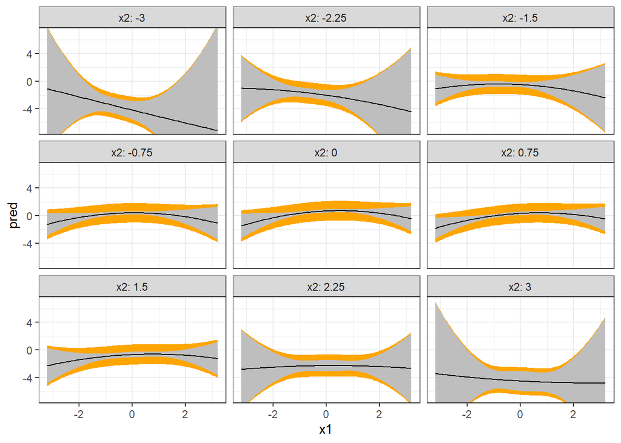

```r
pred_lm_03 %>%
  ggplot(mapping = aes(x = x1)) +
  geom_ribbon(mapping = aes(ymin = pred_lwr, ymax = pred_upr),
              fill = 'orange') +
  geom_ribbon(mapping = aes(ymin = ci_lwr, ymax = ci_upr),
              fill = 'grey') +
  geom_line(mapping = aes(y = pred),
            color = 'black') +
  coord_cartesian(ylim = c(-7, 7)) +
  facet_wrap(~x2, labeller = "label_both") +
  theme_bw()
```

The predictions associated with `mod04` are shown below.

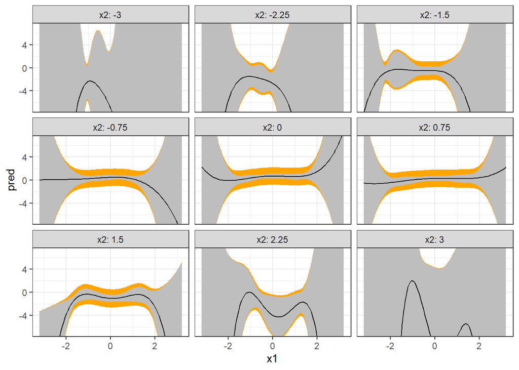

```r
pred_lm_04 %>%
  ggplot(mapping = aes(x = x1)) +
  geom_ribbon(mapping = aes(ymin = pred_lwr, ymax = pred_upr),
              fill = 'orange') +
  geom_ribbon(mapping = aes(ymin = ci_lwr, ymax = ci_upr),
              fill = 'grey') +
  geom_line(mapping = aes(y = pred),
            color = 'black') +
  coord_cartesian(ylim = c(-7, 7)) +
  facet_wrap(~x2, labeller = "label_both") +
  theme_bw()
```

The predictions associated with `mod05` are shown below.

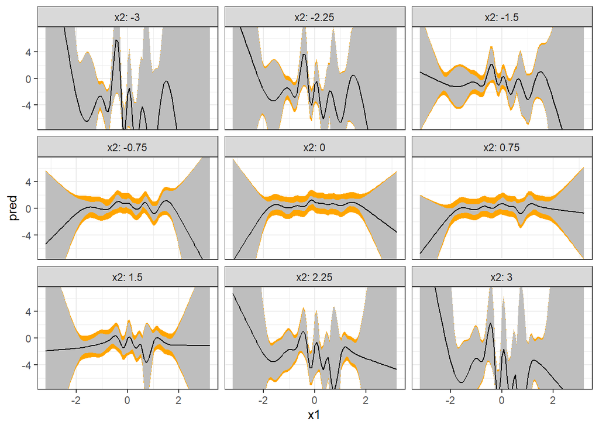

```r
pred_lm_05 %>%
  ggplot(mapping = aes(x = x1)) +
  geom_ribbon(mapping = aes(ymin = pred_lwr, ymax = pred_upr),
              fill = 'orange') +
  geom_ribbon(mapping = aes(ymin = ci_lwr, ymax = ci_upr),
              fill = 'grey') +
  geom_line(mapping = aes(y = pred),
            color = 'black') +
  coord_cartesian(ylim = c(-7, 7)) +
  facet_wrap(~x2, labeller = "label_both") +
  theme_bw()
```

The predictions associated with `mod06` are shown below.

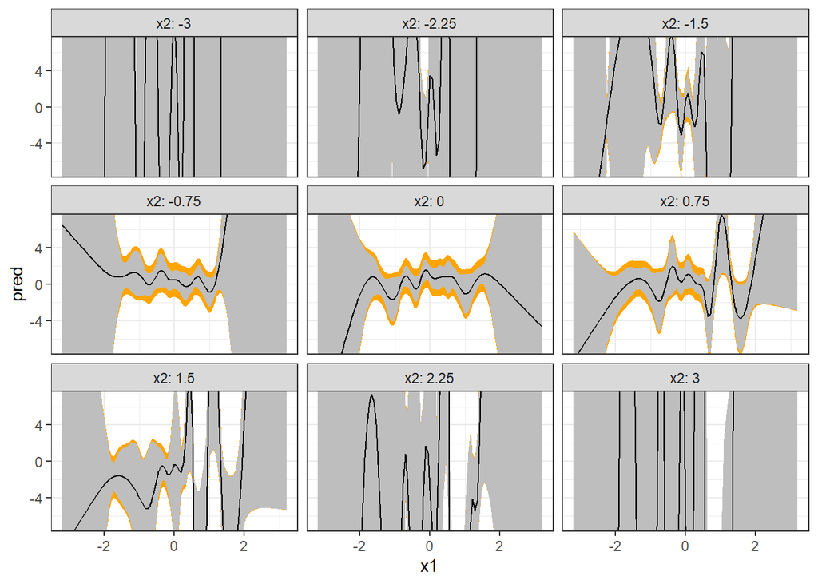

```r
pred_lm_06 %>%
  ggplot(mapping = aes(x = x1)) +
  geom_ribbon(mapping = aes(ymin = pred_lwr, ymax = pred_upr),
              fill = 'orange') +
  geom_ribbon(mapping = aes(ymin = ci_lwr, ymax = ci_upr),
              fill = 'grey') +
  geom_line(mapping = aes(y = pred),
            color = 'black') +
  coord_cartesian(ylim = c(-7, 7)) +
  facet_wrap(~x2, labeller = "label_both") +
  theme_bw()
```

You were required to create separate graphics for each model, but it could be useful to combine multiple models into a single graphic. You were not required to do this, but the code chunk shows the separate models via horizontal facets with the different values of `x2` shown by the vertical facets. The default figure size was modified in the RMarkdown code chunk options by setting `fig.width=12` to make the figure larger than usual to make it easier to see each facet.

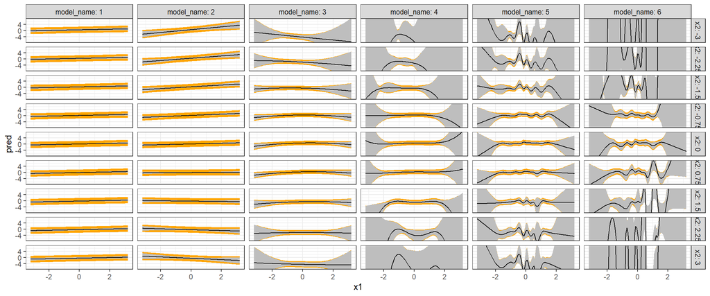

```r
purrr::map2_dfr(list(pred_lm_01, pred_lm_02, pred_lm_03,
                     pred_lm_04, pred_lm_05, pred_lm_06),
                as.character(1:6),
                function(ll, lid){ll %>% mutate(model_name = lid)}) %>%
  ggplot(mapping = aes(x = x1)) +
  geom_ribbon(mapping = aes(ymin = pred_lwr, ymax = pred_upr,
                            group = interaction(model_name, x2)),
              fill = 'orange') +
  geom_ribbon(mapping = aes(ymin = ci_lwr, ymax = ci_upr,
                            group = interaction(model_name, x2)),
              fill = 'grey') +
  geom_line(mapping = aes(y = pred,
                          group = interaction(model_name, x2)),
            color = 'black') +
  coord_cartesian(ylim = c(-7, 7)) +
  facet_grid(x2 ~ model_name, labeller = "label_both") +
  theme_bw()
```

We could even include a `filter()` function to focus on a few values of `x2` and thus reduce the number of vertical facets in the graphic. For example, the code chunk below shows how to filter to four `x2` values.

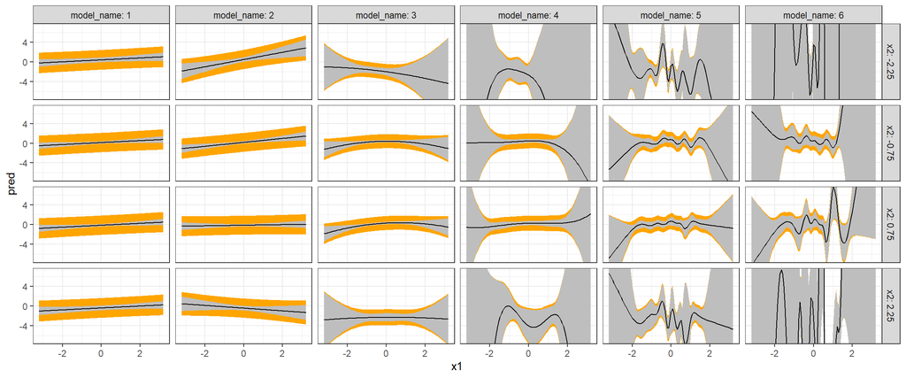

```r
purrr::map2_dfr(list(pred_lm_01, pred_lm_02, pred_lm_03,
                     pred_lm_04, pred_lm_05, pred_lm_06),
                as.character(1:6),
                function(ll, lid){ll %>% mutate(model_name = lid)}) %>%
  filter(x2 %in% c(-2.25, -0.75, 0.75, 2.25)) %>%
  ggplot(mapping = aes(x = x1)) +
  geom_ribbon(mapping = aes(ymin = pred_lwr, ymax = pred_upr,
                            group = interaction(model_name, x2)),
              fill = 'orange') +
  geom_ribbon(mapping = aes(ymin = ci_lwr, ymax = ci_upr,
                            group = interaction(model_name, x2)),
              fill = 'grey') +
  geom_line(mapping = aes(y = pred,
                          group = interaction(model_name, x2)),
            color = 'black') +
  coord_cartesian(ylim = c(-7, 7)) +
  facet_grid(x2 ~ model_name, labeller = "label_both") +
  theme_bw()
```

### 2d)

**Do you feel the predictions are consistent with the model performance rankings based on AIC/BIC? What is the defining characteristic of the models considered to be the worst by AIC/BIC?**

#### SOLUTION

As we examine the predictions from model 1 through model 6, we see the trend (the black line) become more and more “wiggly” and the confidence interval (grey ribbon) growing larger in size. Looking closely at the figures, we also see the prediction interval “shell” (the outer orange ribbon) appearing to shrink relative to the confidence interval. The shrinking prediction interval “shell” is due to the model’s training set error decreases as the complexity increases. The confidence interval is growing however because there are many different ways to combine the features and still approximate the training data. This concept was previously visualized when we examined the coefficient summaries. The coefficient confidence intervals were very wide for the more complex models.

The predictions are consistent with the AIC/BIC results, because the most complex models are highly uncertain about the behavior of the mean trend. The seemingly “wild” oscillations of the trend are the result of the complex models *overfitting* to the training data. If we assessed performance on the training set alone, we would not have observed this behavior. The highly uncertain mean is clearly depicted however when we examine the predictive trends on new data not used in the training process at all.

You were not required to do this, but to illustrate this concept further the code chunk below predicts the training set for `mod03` and `mod06`.

```r
train_set_preds_df <- tidy_predict(mod03, df) %>%
  mutate(mod_name = "3") %>%
  tibble::rowid_to_column("obs_id") %>%
  bind_rows(tidy_predict(mod06, df) %>%
              mutate(mod_name = "6") %>%
              tibble::rowid_to_column("obs_id"))
```

The predictions are visualized with respect to each input in the figure below. The horizontal facets correspond to the two models (`mod03` on the left and `mod06` on the right). The vertical facets denote the input, with `x2` shown in the bottom row. Visualizing the predictions this way makes it easier to see the parabolic influence `x2` has the mean trend. However, it is important to highlight that we cannot connect the predictions with lines (for the trend) and ribbons (for the uncertainty intervals) because the training data are not necessarily sequential! For reference, each facet includes the observed training data as red squares.

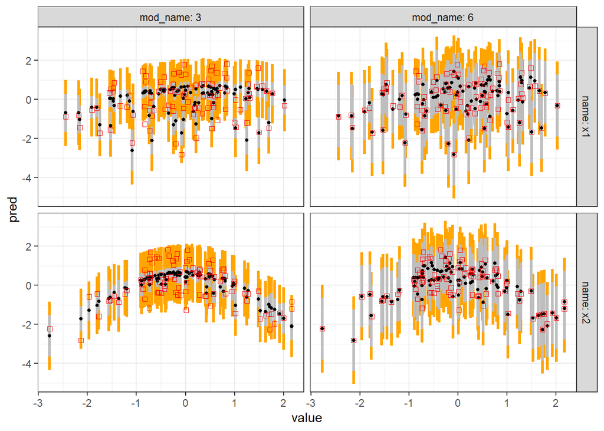

```r
train_set_preds_df %>%
  pivot_longer(starts_with("x")) %>%
  ggplot(mapping = aes(x = value)) +
  geom_linerange(mapping = aes(ymin = pred_lwr,
                               ymax = pred_upr,
                               group = interaction(name, mod_name, obs_id)),
                 size = 1.2, color = 'orange') +
  geom_linerange(mapping = aes(ymin = ci_lwr,
                               ymax = ci_upr,
                               group = interaction(name, mod_name, obs_id)),
                 size = 1.2, color = 'grey') +
  geom_point(mapping = aes(y = pred),
             size = 1, color = 'black') +
  geom_point(data = df %>%
               tibble::rowid_to_column("obs_id") %>%
               pivot_longer(starts_with("x")),
             mapping = aes(x = value, y = y),
             color = 'red', shape = 0) +
  facet_grid(name ~ mod_name, labeller = "label_both") +
  theme_bw()
```

The training set predictions from `mod06` also reveal the large confidence interval compared with `mod03`. The confidence intervals were much larger in the visualization grid figures because we were visualizing predictions at input values not included in the training set. Generalizing to new data is much harder for the *overfit* model because the model is flexible enough to drive down the training error as much as possible. That is why the black dots are closer to the red squares for `mod06` than `mod03` in the above figure.

Essentially, if we only consider training set error metrics, we are assessing performance irrespective of the uncertainty in the coefficients. The figure below shows the training set predictions again for both models, but the uncertainty intervals have been removed. Presented this way, it appears that `mod03` is simply not flexible enough to capture the variation in the training data compared with `mod06`.

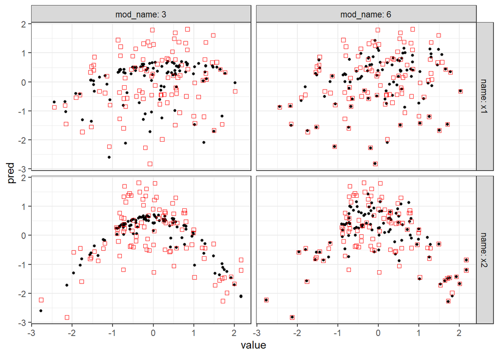

```r
train_set_preds_df %>%
  pivot_longer(starts_with("x")) %>%
  ggplot(mapping = aes(x = value)) +
  geom_point(mapping = aes(y = pred),
             size = 1, color = 'black') +
  geom_point(data = df %>%
               tibble::rowid_to_column("obs_id") %>%
               pivot_longer(starts_with("x")),
             mapping = aes(x = value, y = y),
             color = 'red', shape = 0) +
  facet_grid(name ~ mod_name, labeller = "label_both") +
  theme_bw()
```

The same mistake would be made if we only considered the training set R-squared. The figure below shows the training set predicted-vs-observed figure for the two models. We have already seen that `mod06` has a higher training set R-squared than `mod03`. The figure below is just the graphical version of that statement.

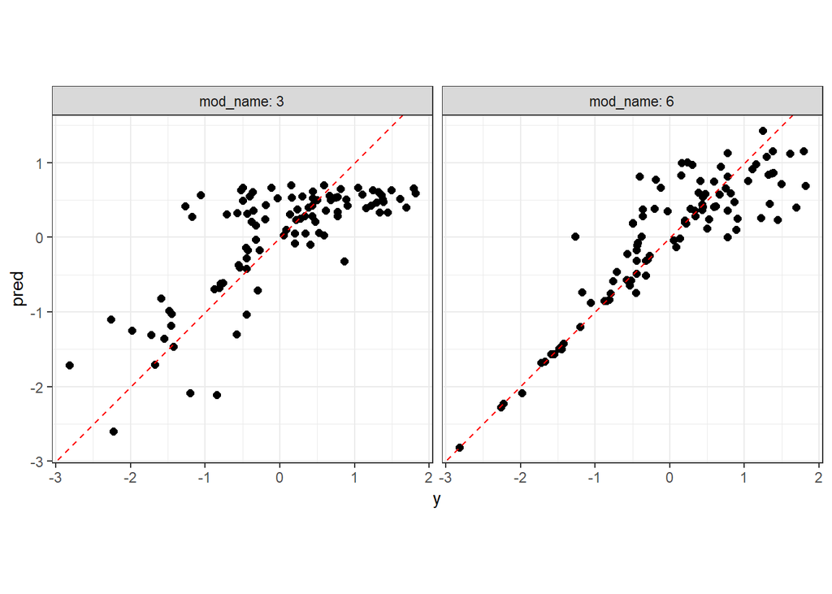

```r
train_set_preds_df %>%
  ggplot(mapping = aes(x = y, y = pred)) +
  geom_point(size = 2) +
  geom_abline(slope = 1, intercept = 0,
              color = 'red', linetype = 'dashed') +
  coord_equal() +
  facet_wrap(~mod_name, labeller = "label_both") +
  theme_bw()
```

## Problem 03

Now that you have fit non-Bayesian linear models with maximum likelihood estimation, it is time to use Bayesian models to understand the influence of the prior on the model behavior.

Regardless of your answers in Problem 02 you will only work with model 3 and model 6 in this problem.

### 3a)

You will perform the Bayesian analysis using the Laplace Approximation just as you did in the previous assignment. You will define the log-posterior function just as you did in the previous assignment and so before doing so you must create the list of required information. This list will include the observed response, the design matrix, and the prior specification. You will use independent Gaussian priors on the regression parameters with a shared prior mean and shared prior standard deviation. You will use an Exponential prior on the unknown likelihood noise (the $\sigma$ parameter).

**Complete the two code chunks below. In the first, create the design matrix following `mod03`’s formula, and assign the object to the `X03` variable. Complete the `info_03_weak` list by assigning the response to `yobs` and the design matrix to `design_matrix`. Specify the shared prior mean, `mu_beta`, to be 0, the shared prior standard deviation, `tau_beta`, as 50, and the rate parameter on the noise, `sigma_rate`, to be 1.**

**Complete the second code chunk with the same prior specification. The second code chunk however requires that you create the design matrix associated with `mod06`’s formula and assign the object to the `X06` variable. Assign `X06` to the `design_matrix` field of the `info_06_weak` list.**

#### SOLUTION

```r
X03 <- model.matrix(y ~ (x1 + I(x1^2)) * (x2 + I(x2^2)), data = df)

info_03_weak <- list(
  yobs = df$y,
  design_matrix = X03,
  mu_beta = 0,
  tau_beta = 50,
  sigma_rate = 1
)
```

```r
X06 <- model.matrix(y ~ splines::ns(x1, 12) * (x2 + I(x2^2) + I(x2^3) + I(x2^4)), data = df)

info_06_weak <- list(
  yobs = df$y,
  design_matrix = X06,
  mu_beta = 0,
  tau_beta = 50,
  sigma_rate = 1
)
```

### 3b)

You will now define the log-posterior function `lm_logpost()`. You will continue to use the log-transformation on $\sigma$, and so you will actually define the log-posterior in terms of the mean trend $\boldsymbol{\beta}$-parameters and the unbounded noise parameter, $\varphi = \log\left[\sigma\right]$.

The comments in the code chunk below tell you what you need to fill in. The unknown parameters to learn are contained within the first input argument, `unknowns`. You will assume that the unknown $\boldsymbol{\beta}$-parameters are listed before the unknown $\varphi$ parameter in the `unknowns` vector. You must specify the number of $\boldsymbol{\beta}$ parameters programmatically to allow scaling up your function to an arbitrary number of unknowns. You will assume that all variables contained in the `my_info` list (the second argument to `lm_logpost()`) are the same fields in the `info_03_weak` list you defined in Problem 3a).

**Define the log-posterior function by completing the code chunk below. You must calculate the mean trend, `mu`, using matrix math between the design matrix and the unknown $\boldsymbol{\beta}$ column vector.**

*HINT*: This function should look very famaliar…

#### SOLUTION

```r
lm_logpost <- function(unknowns, my_info)
{
  # specify the number of unknown beta parameters
  length_beta <- ncol(my_info$design_matrix)

  # extract the beta parameters from the `unknowns` vector
  beta_v <- unknowns[1:length_beta]

  # extract the unbounded noise parameter, varphi
  lik_varphi <- unknowns[length_beta + 1]

  # back-transform from varphi to sigma
  lik_sigma <- exp(lik_varphi)

  # extract design matrix
  X <- my_info$design_matrix

  # calculate the linear predictor
  mu <- as.vector( X %*% as.matrix(beta_v) )

  # evaluate the log-likelihood
  log_lik <- sum(dnorm(x = my_info$yobs,
                       mean = mu,
                       sd = lik_sigma,
                       log = TRUE))

  # evaluate the log-prior
  log_prior_beta <- sum(dnorm(x = beta_v,
                              mean = my_info$mu_beta,
                              sd = my_info$tau_beta,
                              log = TRUE))

  log_prior_sigma <- dexp(x = lik_sigma,
                          rate = my_info$sigma_rate,
                          log = TRUE)

  # add the mean trend prior and noise prior together
  log_prior <- log_prior_beta + log_prior_sigma

  # account for the transformation
  log_derive_adjust <- lik_varphi

  # sum together
  log_lik + log_prior + log_derive_adjust
}
```

### 3c)

The `my_laplace()` function is defined for you in the code chunk below. This function executes the laplace approximation and returns the object consisting of the posterior mode, posterior covariance matrix, and the log-evidence.

```r
my_laplace <- function(start_guess, logpost_func, ...)
{
  # code adapted from the `LearnBayes`` function `laplace()`
  fit <- optim(start_guess,
               logpost_func,
               gr = NULL,
               ...,
               method = "BFGS",
               hessian = TRUE,
               control = list(fnscale = -1, maxit = 1001))

  mode <- fit$par
  post_var_matrix <- -solve(fit$hessian)
  p <- length(mode)
  int <- p/2 * log(2 * pi) + 0.5 * log(det(post_var_matrix)) + logpost_func(mode, ...)
  # package all of the results into a list
  list(mode = mode,
       var_matrix = post_var_matrix,
       log_evidence = int,
       converge = ifelse(fit$convergence == 0,
                         "YES",
                         "NO"),
       iter_counts = as.numeric(fit$counts[1]))
}
```

**Execute the Laplace Approximation for the model 3 formulation and the model 6 formulation. Assign the model 3 result to the `laplace_03_weak` object, and assign the model 6 result to the `laplace_06_weak` object. Check that the optimization scheme converged.**

#### SOLUTION

The Laplace Approximation is execute for both models below.

```r
laplace_03_weak <- my_laplace(rep(0, ncol(X03)+1), lm_logpost, info_03_weak)

laplace_06_weak <- my_laplace(rep(0, ncol(X06)+1), lm_logpost, info_06_weak)
```

As shown below, the optimization schemes for both models converged.

```r
laplace_03_weak$converge
```

```
## [1] "YES"
```

```r
laplace_06_weak$converge
```

```
## [1] "YES"
```

### 3d)

A function is defined for you in the code chunk below. This function creates a coefficient summary plot in the style of the `coefplot()` function, but uses the Bayesian results from the Laplace Approximation. The first argument is the vector of posterior means, and the second argument is the vector of posterior standard deviations. The third argument is the name of the feature associated with each coefficient.

```r
viz_post_coefs <- function(post_means, post_sds, xnames)
{
  tibble::tibble(
    mu = post_means,
    sd = post_sds,
    x = xnames
  ) %>%
    mutate(x = factor(x, levels = xnames)) %>%
    ggplot(mapping = aes(x = x)) +
    geom_hline(yintercept = 0, color = 'grey', linetype = 'dashed') +
    geom_point(mapping = aes(y = mu)) +
    geom_linerange(mapping = aes(ymin = mu - 2 * sd,
                                 ymax = mu + 2 * sd,
                                 group = x)) +
    labs(x = 'feature', y = 'coefficient value') +
    coord_flip() +
    theme_bw()
}
```

**Create the posterior summary visualization figure for model 3 and model 6. You must provide the posterior means and standard deviations of the regression coefficients (the $\beta$ parameters). Do NOT include the $\varphi$ parameter. The feature names associated with the coefficients can be extracted from the design matrix using the `colnames()` function.**

#### SOLUTION

The coefficient posterior summaries for `mod03` are visualized below. Notice that the number of columns in the `X03` design matrix are used to identify the number of regression coefficients (beta parameters).

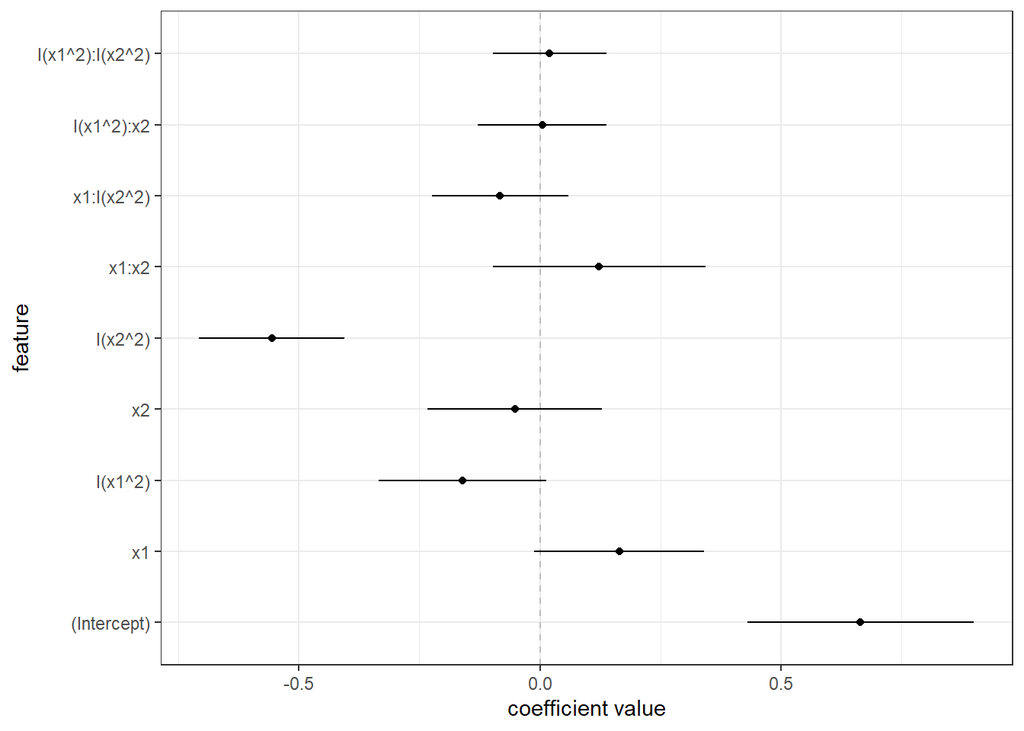

```r
viz_post_coefs(laplace_03_weak$mode[1:ncol(X03)],
               sqrt(diag(laplace_03_weak$var_matrix)[1:ncol(X03)]),
               colnames(X03))
```

Likewise, the posterior coefficient summaries for `mod06` are shown below. Again the number of columns in the design matrix is used to identify the regression coefficients.

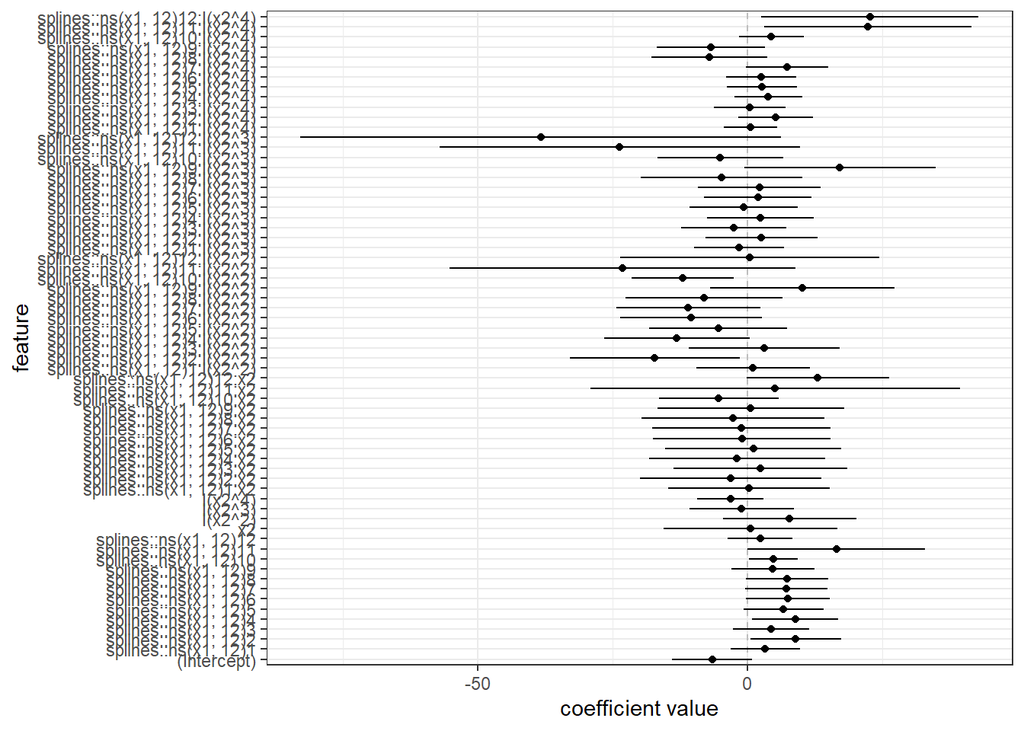

```r
viz_post_coefs(laplace_06_weak$mode[1:ncol(X06)],
               sqrt(diag(laplace_06_weak$var_matrix)[1:ncol(X06)]),
               colnames(X06))
```

### 3e)

**Use the Bayes Factor to identify the better of the models.**

#### SOLUTION

The Bayes Factor is calculated using the Laplace Approximation’s log-evidence approximation. After exponentiating each model’s log-evidence, the Bayes Factor is the ratio of the evidences.

```r
exp(laplace_03_weak$log_evidence) / exp(laplace_06_weak$log_evidence)
```

```
## [1] 1.483405e+88
```

Alternatively, we can use log-arithmetic to calculate the Bayes Factor. An equivalent approach is to exponentiate the difference of the log-evidences.

```r
exp( laplace_03_weak$log_evidence - laplace_06_weak$log_evidence )
```

```
## [1] 1.483405e+88
```

Either approach gives the same result. A Bayes Factor greater than 1 represents there is more “evidence” to support the “numerator model” compared to the model in the denominator. As shown above the Bayes Factor is on the order of 1E88. This is a huge number! Essentially, the log-evidence (via the Bayes Factor) feels there is no reason to consider `mod06` compared to `mod03`. The Bayes Factor is telling us that the training set performance of `mod06` does not matter, this model will not generalize to new data.

### 3f)

You fit the Bayesian models assuming a diffuse or *weak* prior. Let’s now try a more informative or *strong* prior by reducing the prior standard deviation on the regression coefficients from 50 to 1. The prior mean will still be zero.

**Complete the first code chunk below, which defines the list of required information for both the model 3 and model 6 formulations using the strong prior on the regression coefficients. All other information, data and the $\sigma$ prior, are the same as before.**

**Run the Laplace Approximation using the strong prior for both the model 3 and model 6 formulations. Assign the results to `laplace_03_strong` and `laplace_06_strong`.**

**Confirm that the optimizations converged for both laplace approximation results.**

#### SOLUTION

Define the lists of required information for the strong prior.

```r
info_03_strong <- list(
  yobs = df$y,
  design_matrix = X03,
  mu_beta = 0,
  tau_beta = 1,
  sigma_rate = 1
)

info_06_strong <- list(
  yobs = df$y,
  design_matrix = X06,
  mu_beta = 0,
  tau_beta = 1,
  sigma_rate = 1
)
```

Execute the Laplace Approximation.

```r
laplace_03_strong <- my_laplace(rep(0, ncol(X03)+1), lm_logpost, info_03_strong)

laplace_06_strong <- my_laplace(rep(0, ncol(X06)+1), lm_logpost, info_06_strong)
```

As shown below, the optimizations did converge for both models.

```r
purrr::map_chr(list(laplace_03_strong, laplace_06_strong), "converge")
```

```
## [1] "YES" "YES"
```

### 3g)

**Use the `viz_post_coefs()` function to visualize the posterior coefficient summaries for model 3 and model 6, based on the strong prior specification.**

#### SOLUTION

The posterior coefficient summaries for `mod03` appear to be basically the same as what we saw with the weak prior! This should not be surprising because we previously saw that the posterior means for all `mod03` coefficients were between -1 and +1. Our stronger prior therefore is restricting the coefficients to the range the data (likelihood) was supporting anyway! Thus, the posterior for this particular model and data is not influenced by this specific prior.

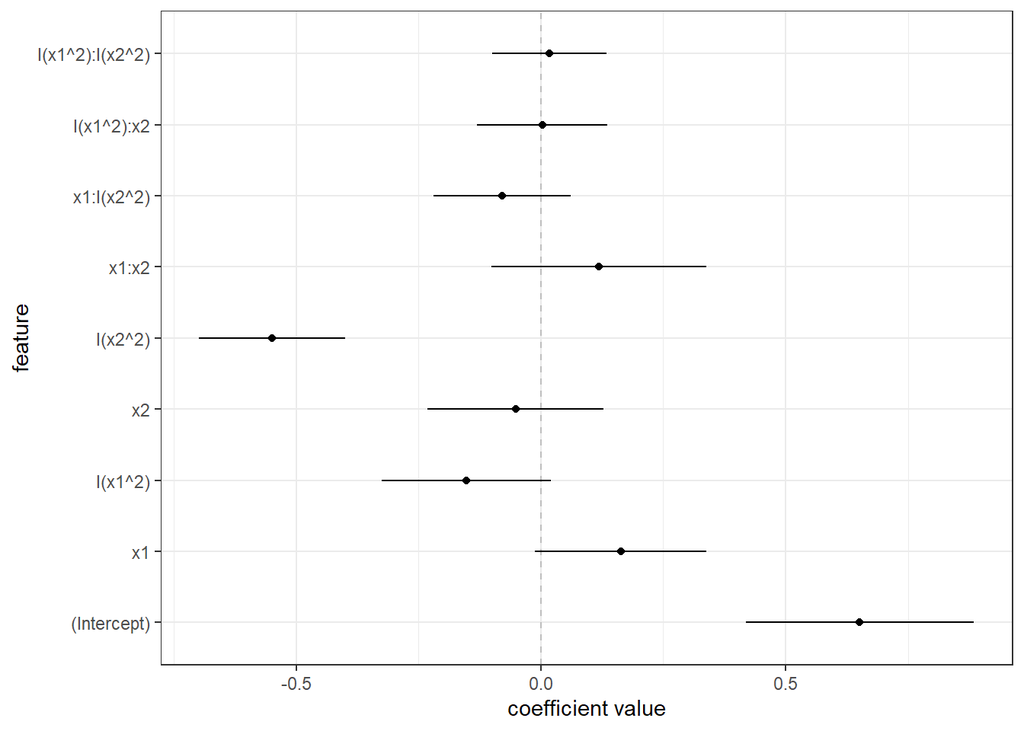

```r
viz_post_coefs(laplace_03_strong$mode[1:ncol(X03)],
               sqrt(diag(laplace_03_strong$var_matrix)[1:ncol(X03)]),
               colnames(X03))
```

The posterior coefficient summaries based on the strong prior for `mod06` are shown below. At first glance, we may think that coefficient posteriors are still very uncertain for `mod06`. However, it is important to note the x-axis scale in the figure. The figure below has all coefficient posterior means between -1 and +1! The posterior coefficient summaries for `mod06` associated with the weak prior covered a much wider range. Many of the coefficients had posterior means in the double digits when we used the weak prior. The more restrictive “strong” prior with prior standard deviation of 1 is thus preventing the coefficients from reaching the values supported by the data alone for `mod06`!

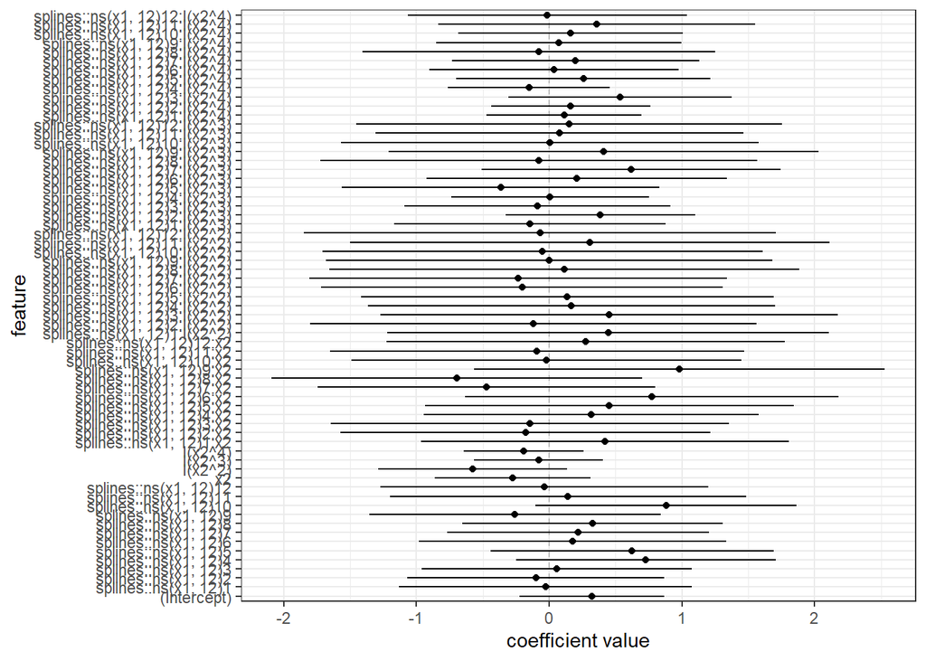

```r
viz_post_coefs(laplace_06_strong$mode[1:ncol(X06)],
               sqrt(diag(laplace_06_strong$var_matrix)[1:ncol(X06)]),
               colnames(X06))
```

### 3h)

You will fit one more set of Bayesian models with a very strong prior on the regression coefficients. The prior standard deviation will be equal to 1/50.

**Complete the first code chunk below, which defines the list of required information for both the model 3 and model 6 formulations using the very strong prior on the regression coefficients. All other information, data and the $\sigma$ prior, are the same as before.**

**Run the Laplace Approximation using the strong prior for both the model 3 and model 6 formulations. Assign the results to `laplace_03_very_strong` and `laplace_06_very_strong`.**

**Confirm that the optimizations converged for both laplace approximation results.**

#### SOLUTION

```r
info_03_very_strong <- list(
  yobs = df$y,
  design_matrix = X03,
  mu_beta = 0,
  tau_beta = 1/50,
  sigma_rate = 1
)

info_06_very_strong <- list(
  yobs = df$y,
  design_matrix = X06,
  mu_beta = 0,
  tau_beta = 1/50,
  sigma_rate = 1
)
```

Execute the Laplace Approximation.

```r
laplace_03_very_strong <- my_laplace(rep(0, ncol(X03)+1), lm_logpost, info_03_very_strong)

laplace_06_very_strong <- my_laplace(rep(0, ncol(X06)+1), lm_logpost, info_06_very_strong)
```

As shown below, the optimization algorithms converged for both models.

```r
purrr::map_chr(list(laplace_03_very_strong, laplace_06_very_strong), "converge")
```

```
## [1] "YES" "YES"
```

### 3i)

**Use the `viz_post_coefs()` function to visualize the posterior coefficient summaries for model 3 and model 6, based on the very strong prior specification.**

#### SOLUTION

Based on the figure below, we might be tempted to think the coefficients for `mod03` based on the very strong prior are quite uncertain. However, pay close attention to the x-axis scale. All posterior means are between -0.05 and +0.05! The apparent “wide” uncertainty intervals is just due to the x-axis scale. The posterior uncertainty intervals are confined to a narrow interval relative to the posterior associated with the weak and strong priors.

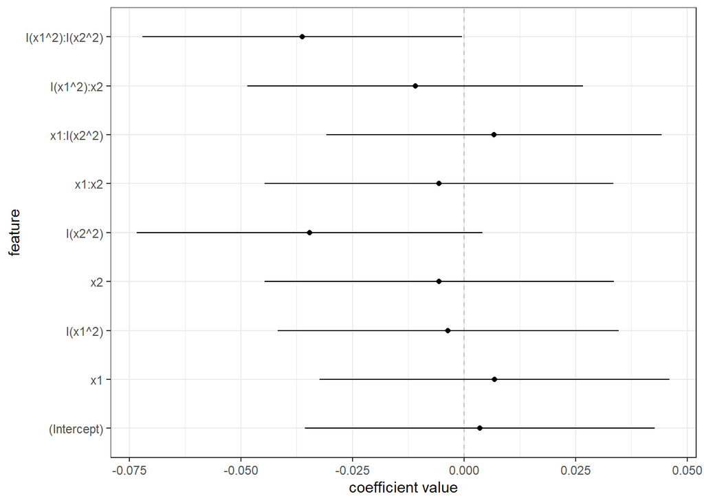

```r
viz_post_coefs(laplace_03_very_strong$mode[1:ncol(X03)],
               sqrt(diag(laplace_03_very_strong$var_matrix)[1:ncol(X03)]),
               colnames(X03))
```

Likewise, the posterior uncertainty intervals for the coefficients in `mod06` are also confined to a narrow interval.

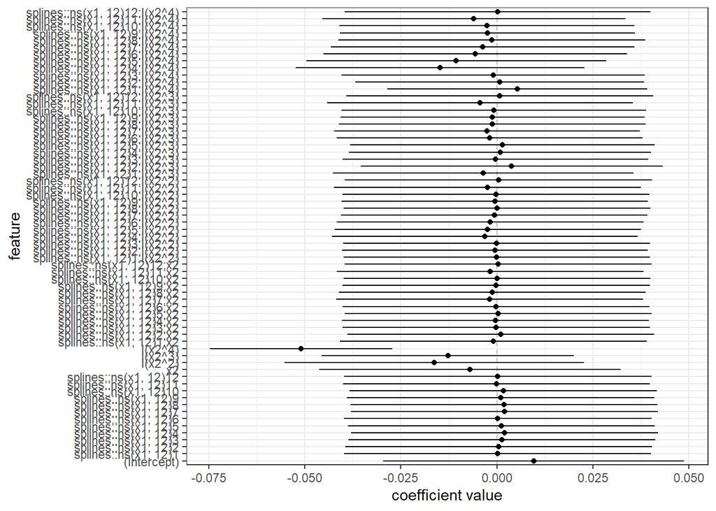

```r
viz_post_coefs(laplace_06_very_strong$mode[1:ncol(X06)],
               sqrt(diag(laplace_06_very_strong$var_matrix)[1:ncol(X06)]),
               colnames(X06))
```

### 3j)

**Describe the influence of the regression coefficient prior standard deviation on the coefficient posterior distributions.**

#### SOLUTION

The prior “strength” is controlled by the prior standard deviation. The prior standard deviation determines the “allowable range” of the coefficients. The larger the prior standard deviation is, the less influence the prior will have and thus the likelihood will allow the coefficients to take on whatever values are necessary. However, by using smaller prior standard deviations, we can limit the allowable parameters the coefficients can take. This prevents the likelihood from dictating the coefficients to be whatever values minimize the error as much as possible.

Although you were not required to do this, the figure below combines the coefficient posterior summaries based on the three different priors for `mod03`. As shown below, the very strong prior with $\tau_{\beta} = 1/50$ is strong enough to “pull” the coefficient posterior means very close to zero.

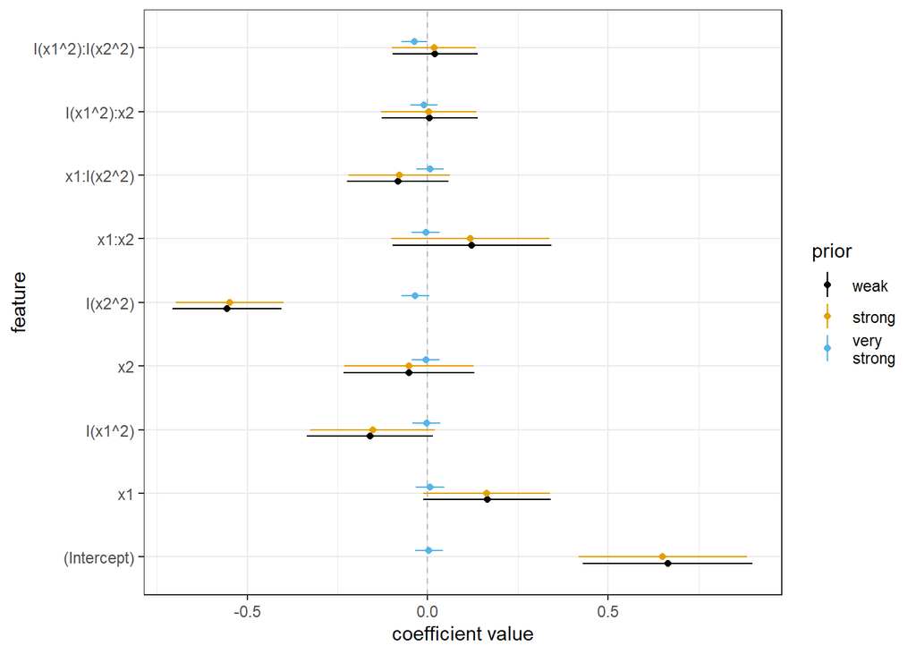

```r
purrr::map2_dfr(list(laplace_03_weak,
                     laplace_03_strong,
                     laplace_03_very_strong),
                c("weak", "strong", "very\nstrong"),
                function(ll, tb, X){
                  nb <- ncol(X)
                  ns <- colnames(X)
                  ms <- ll$mode[1:nb]
                  sds <- sqrt(diag(ll$var_matrix))[1:nb]

                  tibble::tibble(
                    mu = ms, sd = sds, x = ns
                  ) %>%
                    mutate(prior = tb)
                },
                X = X03) %>%
  mutate(x = factor(x, levels = colnames(X03))) %>%
  mutate(prior = factor(prior, levels = c('weak', 'strong', 'very\nstrong'))) %>%
  ggplot(mapping = aes(x = x)) +
  geom_hline(yintercept = 0, color = 'grey', linetype = 'dashed') +
  geom_point(mapping = aes(y = mu,
                           color = prior,
                           group = interaction(x, prior)),
             position = position_dodge(0.3)) +
  geom_linerange(mapping = aes(ymin = mu - 2 * sd,
                               ymax = mu + 2 * sd,
                               group = interaction(x, prior),
                               color = prior),
                 position = position_dodge(0.3)) +
  labs(x = 'feature', y = 'coefficient value') +
  coord_flip() +
  ggthemes::scale_color_colorblind() +
  theme_bw()
```

The analogous figure is created for `mod06` below. The feature labels on the vertical axis were removed because there are so many features the labels are difficult to read. Removing them gives more space for the plot, which is the primary importance here. The weak prior’s associated coefficient posterior summaries have very large posterior means. The likelihood is allowed to do “whatever it wants” because the prior is not restrictive. The stronger priors with smaller prior standard deviations do not give the likelihood the freedom to do whatever it wants. The stronger priors place constraints on the allowable parameter values.

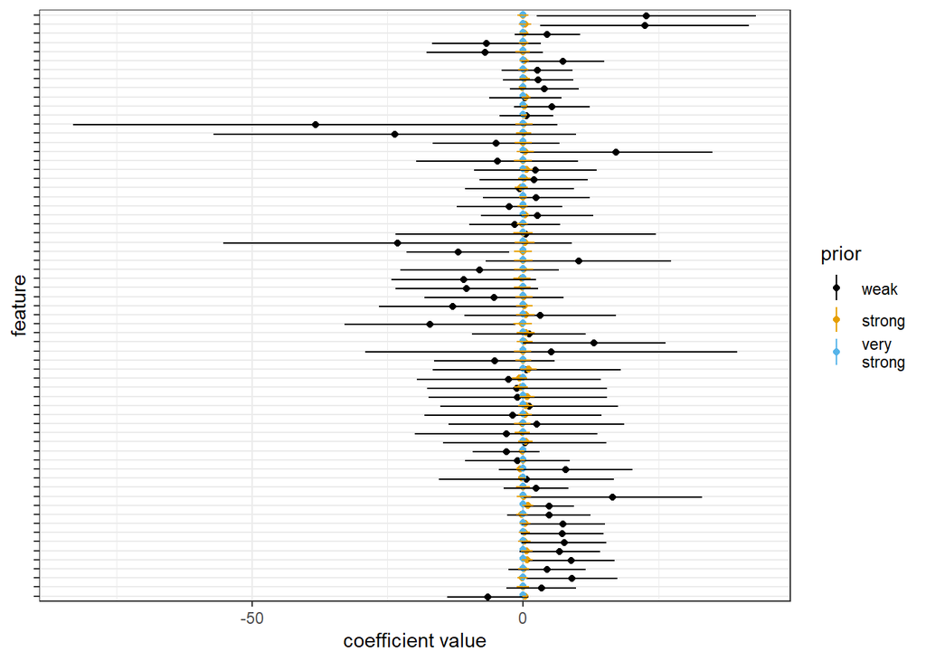

```r
purrr::map2_dfr(list(laplace_06_weak,
                     laplace_06_strong,
                     laplace_06_very_strong),
                c("weak", "strong", "very\nstrong"),
                function(ll, tb, X){
                  nb <- ncol(X)
                  ns <- colnames(X)
                  ms <- ll$mode[1:nb]
                  sds <- sqrt(diag(ll$var_matrix))[1:nb]

                  tibble::tibble(
                    mu = ms, sd = sds, x = ns
                  ) %>%
                    mutate(prior = tb)
                },
                X = X06) %>%
  mutate(x = factor(x, levels = colnames(X06))) %>%
  mutate(prior = factor(prior, levels = c('weak', 'strong', 'very\nstrong'))) %>%
  ggplot(mapping = aes(x = x)) +
  geom_hline(yintercept = 0, color = 'grey', linetype = 'dashed') +
  geom_point(mapping = aes(y = mu,
                           color = prior,
                           group = interaction(x, prior)),
             position = position_dodge(0.3)) +
  geom_linerange(mapping = aes(ymin = mu - 2 * sd,
                               ymax = mu + 2 * sd,
                               group = interaction(x, prior),
                               color = prior),
                 position = position_dodge(0.3)) +
  labs(x = 'feature', y = 'coefficient value') +
  coord_flip() +
  ggthemes::scale_color_colorblind() +
  theme_bw() +
  theme(axis.text.y = element_blank())
```

### 3k)

You previously compared the two models using the Bayes Factor based on the weak prior specification.

**Compare the performance of the two models with Bayes Factors again, but considering the results based on the strong and very strong priors. Does the prior influence which model is considered to be better?**

#### SOLUTIOn

Even though the strong prior pulls the `mod06` coefficients away from the large values, the Bayes Factor reveals that `mod03` is the better of the two models. The Bayes Factor is still so large, we should not consider `mod06` an appropriate model compared to `mod03`.

```r
exp(laplace_03_strong$log_evidence) / exp(laplace_06_strong$log_evidence)
```

```
## [1] 2.672262e+13
```

The models are compared with the Bayes Factor calculated based on the very strong prior below. As we can see, the Bayes Factor is now much less than 1. Thus, `mod06` is now considered better than `mod03`! As we saw with the coefficient summaries, the very strong prior is so overly restrictive the coefficients for `mod03` are all close to zero. Thus, the `mod03` is not able to identify meaningful trends in the data because of the prior. The prior has in effect prevented the model from learning! The much more complicated model `mod06` is considered better when we use the very strong prior because it has the extra flexibility necessary to identify at least some kind of trend in the data.

```r
exp(laplace_03_very_strong$log_evidence) / exp(laplace_06_very_strong$log_evidence)
```

```
## [1] 0.0002438238
```

Of course, what we ultimately care about is a model that predicts well on NEW data. Thus, we would ultimately want to compare the models across all priors! You were not required to do this, because this assignment was focused strictly on the influence of the prior on the coefficients and the predictive trends. However, we could compare across priors to identify the overall best model! For example, the Bayes Factor comparing `mod03` with the strong prior to `mod06` with the very strong prior is calculated below. Again, you were NOT required to do this, but as shown below `mod03` with the strong prior out-performs `mod06` with the very strong prior. Thus, we can conclude our very strong prior is not appropriate because it removes trends! We have more evidence to support a relatively simple model capturing trends compared with a model that has turned off most trends very the very strong and thus limiting prior.

```r
exp(laplace_03_strong$log_evidence) / exp(laplace_06_very_strong$log_evidence)
```

```
## [1] 6.719196
```

## Problem 04

You examined the behavior of the coefficient posterior based on the influence of the prior. Let’s now consider the prior’s influence by examining the posterior predictive distributions.

### 4a)

You will make posterior predictions following the approach from the previous assignment. Posterior samples are generated and those samples are used to calculate the posterior samples of the mean trend and generate random posterior samples of the response around the mean. In the previous assignment, you made posterior predictions in order to calculate errors. In this assignment, you will not calculate errors, instead you will summarize the posterior predictions of the mean and of the random response.

The `generate_lm_post_samples()` function is defined for you below. It uses the `MASS::mvrnorm()` function generate posterior samples from the Laplace Approximation’s MVN distribution.

```r
generate_lm_post_samples <- function(mvn_result, length_beta, num_samples)
{
  MASS::mvrnorm(n = num_samples,
                mu = mvn_result$mode,
                Sigma = mvn_result$var_matrix) %>%
    as.data.frame() %>% tibble::as_tibble() %>%
    purrr::set_names(c(sprintf("beta_%02d", 0:(length_beta-1)), "varphi")) %>%
    mutate(sigma = exp(varphi))
}
```

The code chunk below starts the `post_lm_pred_samples()` function. This function generates posterior mean trend predictions and posterior predictions of the response. The first argument, `Xnew`, is a potentially new or test design matrix that we wish to make predictions at. The second argument, `Bmat`, is a matrix of posterior samples of the $\boldsymbol{\beta}$-parameters, and the third argument, `sigma_vector`, is a vector of posterior samples of the likelihood noise. The `Xnew` matrix has rows equal to the number of predictions points, `M`, and the `Bmat` matrix has rows equal to the number of posterior samples `S`.

You must complete the function by performing the necessary matrix math to calculate the matrix of posterior mean trend predictions, `Umat`, and the matrix of posterior response predictions, `Ymat`. You must also complete missing arguments to the definition of the `Rmat` and `Zmat` matrices. The `Rmat` matrix replicates the posterior likelihood noise samples the correct number of times. The `Zmat` matrix is the matrix of randomly generated standard normal values. You must correctly specify the required number of rows to the `Rmat` and `Zmat` matrices.

The `post_lm_pred_samples()` returns the `Umat` and `Ymat` matrices contained within a list.

**Perform the necessary matrix math to calculate the matrix of posterior predicted mean trends `Umat` and posterior predicted responses `Ymat`. You must specify the number of required rows to create the `Rmat` and `Zmat` matrices.**

*HINT*: The following code chunk should look famaliar…

#### SOLUTION

```r
post_lm_pred_samples <- function(Xnew, Bmat, sigma_vector)
{
  # number of new prediction locations
  M <- nrow(Xnew)
  # number of posterior samples
  S <- nrow(Bmat)

  # matrix of linear predictors
  Umat <- Xnew %*% t(Bmat)

  # assmeble matrix of sigma samples, set the number of rows
  Rmat <- matrix(rep(sigma_vector, M), M, byrow = TRUE)

  # generate standard normal and assemble into matrix
  # set the number of rows
  Zmat <- matrix(rnorm(M*S), M, byrow = TRUE)

  # calculate the random observation predictions
  Ymat <- Umat + Rmat * Zmat

  # package together
  list(Umat = Umat, Ymat = Ymat)
}
```

### 4b)

Since this assignment is focused on visualizing the predictions, we will summarize the posterior predictions to focus on the posterior means and the middle 95% uncertainty intervals. The code chunk below is defined for you which serves as a useful wrapper function to call `post_lm_pred_samples()`.

```r
make_post_lm_pred <- function(Xnew, post)
{
  Bmat <- post %>% select(starts_with("beta_")) %>% as.matrix()

  sigma_vector <- post %>% pull(sigma)

  post_lm_pred_samples(Xnew, Bmat, sigma_vector)
}
```

The code chunk below defines a function `summarize_lm_pred_from_laplace()` which manages the actions necessary to summarize posterior predictions. The first argument, `mvn_result`, is the Laplace Approximation object. The second object is the test design matrix, `Xtest`, and the third argument, `num_samples`, is the number of posterior samples to make.

You must complete the code chunk below which summarizes the posterior predictions. This function takes care of most of the coding for you. You do not have to worry about the generation of the posterior samples OR calculating the posterior quantiles associated with the middle 95% uncertainty interval. You must calculate the posterior average by deciding on whether you should use `colMeans()` or `rowMeans()` to calculate the average across all posterior samples per prediction location.

**Follow the comments in the code chunk below to complete the definition of the summarize_lm_pred_from_laplace() function. You must calculate the average posterior mean trend and the average posterior response.**

#### SOLUTION

```r
summarize_lm_pred_from_laplace <- function(mvn_result, Xtest, num_samples)
{
  # generate posterior samples of the beta parameters
  post <- generate_lm_post_samples(mvn_result, ncol(Xtest), num_samples)

  # make posterior predictions on the test set
  pred_test <- make_post_lm_pred(Xtest, post)

  # calculate summary statistics on the predicted mean and response
  # summarize over the posterior samples

  # posterior mean, should you summarize along rows (rowMeans) or
  # summarize down columns (colMeans) ???
  mu_avg <- rowMeans(pred_test$Umat)
  y_avg <- rowMeans(pred_test$Ymat)

  # posterior quantiles for the middle 95% uncertainty intervals
  mu_lwr <- apply(pred_test$Umat, 1, stats::quantile, probs = 0.025)
  mu_upr <- apply(pred_test$Umat, 1, stats::quantile, probs = 0.975)
  y_lwr <- apply(pred_test$Ymat, 1, stats::quantile, probs = 0.025)
  y_upr <- apply(pred_test$Ymat, 1, stats::quantile, probs = 0.975)

  # book keeping
  tibble::tibble(
    mu_avg = mu_avg,
    mu_lwr = mu_lwr,
    mu_upr = mu_upr,
    y_avg = y_avg,
    y_lwr = y_lwr,
    y_upr = y_upr
  ) %>%
    tibble::rowid_to_column("pred_id")
}
```

### 4c)

When you made predictions in Problem 02, the `lm()` object handled making the test design matrix. However, since we have programmed the Bayesian modeling approach from scratch we need to create the test design matrix manually.

**Create the test design matrix based on the visualization grid, `viz_grid`, using the model 3 formulation. Assign the result to the `X03_test` object.**

**Call the `summarize_lm_pred_from_laplace()` function to summarize the posterior predictions from the model 3 formulation for the weak, strong, and very strong prior specifications. Use 5000 posterior samples for each case. Assign the results from the weak prior to `post_pred_summary_viz_03_weak`, the results from the strong prior to `post_pred_summary_viz_03_strong`, and the results from the very strong prior to `post_pred_summary_viz_03_very_strong`.**

#### SOLUTION

The test design matrix for the visualization grid associated with `mod03` is created below.

```r
X03_test <- model.matrix( ~ (x1 + I(x1^2)) * (x2 + I(x2^2)), data = viz_grid)
```

The posterior predictions are summarized for each prior specification in the code chunk below.

```r
post_pred_summary_viz_03_weak <- summarize_lm_pred_from_laplace(laplace_03_weak,
                                                                X03_test,
                                                                5000)

post_pred_summary_viz_03_strong <- summarize_lm_pred_from_laplace(laplace_03_strong,
                                                                  X03_test,
                                                                  5000)

post_pred_summary_viz_03_very_strong <- summarize_lm_pred_from_laplace(laplace_03_very_strong,
                                                                       X03_test,
                                                                       5000)
```

### 4d)

You will now visualize the posterior predictions from the model 3 Bayesian models associated with the weak, strong, and very strong priors. The `viz_grid` object is joined to the prediction dataframes assuming you have used the correct variable names!

**Visualize the predicted means, confidence intervals, and prediction intervals in the style of those that you created in Problem 02. The confidence interval bounds are `mu_lwr` and `mu_upr` columns and the prediction interval bounds are the `y_lwr` and `y_upr` columns, respectively. The posterior predicted mean of the mean is `mu_avg`.**

**Pipe the result of the joined dataframe into `ggplot()` and make appropriate aesthetics and layers to visualize the predictions with the `x1` variable mapped to the `x` aesthetic and the `x2` variable used as a facet variable.**